# Back-To-School Afghanistan Questionnaire Analysis

### Reading in 2017-2018 Questionnaires as PreQ and PostQ.PrevYear

```r
PostQ.PrevYear <- readRDS("2017-2018PostQBTS.RDS")
PreQ.PrevYear <- readRDS("2017-2018PreQBTS.RDS")

head(PreQ.PrevYear)
```

| Respondent ID | Collector ID | Start Date | End Date | IP Address | Email Address | First Name | Last Name | Custom Data 1 | Project Site | Gender | My experience coming to BTS classes has been | Why (experience coming to BTS classes) | How safe do you feel at Skateistan? | Why (feeling safe at Skateistan) | Confidence since joining the program has | Comment on confidence levels | I have learned a lot of useful skills and lessons since coming to BTS classes at Skateistan | Comment on useful skills learnt | Friends made at Skateistan | How many friends made/background | Role Model - Mother | Role Model - Father | Role Model - Brother/Sister | Role Model - Other family member | Role Model - Friends at Skateistan | Role Model - Skateistan Educator | Role Model - Someone older than me at Skateistan | Role Model - Other | Role Model - Would you like to say who? | … |
| --- | --- | --- | --- | --- | --- | --- | --- | --- | --- | --- | --- | --- | --- | --- | --- | --- | --- | --- | --- | --- | --- | --- | --- | --- | --- | --- | --- | --- | --- | --- |
| 6276971221 | 156472006 | 2017-07-06 08:10:43 | 2017-07-06 08:13:18 | 180.94.84.219 |  |  |  |  | Mazar | Female | Good | I love Skateistan, because every thing is clean and nice here. | Safe | I feel safe. | Gone up a little bit | I am not afraid to raise my hand and read the book. | Agree | I have learned a lots of new words and I learned how to write them. | Yes, one new friend | My friend is my relative. | Mother |  |  |  |  | Skateistan Educator |  |  |  | … |
| 6276967073 | 156472006 | 2017-07-06 08:05:54 | 2017-07-06 08:10:22 | 180.94.84.219 |  |  |  |  | Mazar | Female | Good | Our teacher is kind and help me to learn the lesson quickly. | Safe | I feel safe. | Gone up a little bit | When some one bother me I can say to my teacher. | Agree | I have learn about life skill, Dari and Math. | Yes, one new friend | I have one friend, she is Uzabek. | Mother |  |  |  |  | Skateistan Educator |  |  |  | … |
| 6276945583 | 156472006 | 2017-07-06 07:53:49 | 2017-07-06 07:57:05 | 180.94.84.219 |  |  |  |  | Mazar | Female | Good | I like Skateistan facility. | Safe | I am feeling safe because there are guards inside Skateistan. | Gone up a little bit | I can talk in front of the class, I am not afraid to write and read the words. | Agree | I have learnt how to use the toilet, I have never used it before in our house, how to respect others and how to read and write. | Yes, one new friend | My friends are Arab. | Mother |  |  |  |  |  |  |  |  | … |
| 6275357623 | 156472006 | 2017-07-05 12:01:21 | 2017-07-05 12:04:35 | 111.125.153.178 |  |  |  |  | Mazar | Female | Good | i like writing | Safe |  | Gone up a little bit | i can read now. | Agree | Dari, math, life skill. | Yes, more than one new friend | they are Uzbike |  |  |  |  |  | Skateistan Educator |  |  |  | … |
| 6275353883 | 156472006 | 2017-07-05 11:58:13 | 2017-07-05 12:01:01 | 111.125.153.178 |  |  |  |  | Mazar | Female | Good | i like studying | Safe |  | Gone up a little bit | i can read and write now | Agree | alphabet, numbers, drawing | Yes, more than one new friend | they are my relatives |  |  |  |  | Friends at Skateistan |  |  |  |  | … |
| 6275350664 | 156472006 | 2017-07-05 11:51:40 | 2017-07-05 11:58:00 | 111.125.153.178 |  |  |  |  | Mazar | Male | Very Good | i like writing | Safe |  | Gone up a lot | I am not shame | Agree | Math, drawing, Dari | Yes, one new friend |  | Mother |  |  |  | Friends at Skateistan |  |  |  |  | … |

```r
head(PostQ.PrevYear)
```

| Respondent ID | Collector ID | Start Date | End Date | IP Address | Email Address | First Name | Last Name | Custom Data 1 | Project Site | Group Name | Name | Gender | My experience coming to BTS classes has been | Comment (experience coming to BTS classes) | How safe do you feel at Skateistan? | Comment (safety at Skateistan) | Confidence since joining the program has | Comment (confidence since joining Skateistan) | I have learned a lot of useful skills and lessons since coming to BTS classes at Skateistan | Comment (what you have learnt) | Friends made at Skateistan | Comment (on friends made) | Role Model - Mother | Role Model - Father | Role Model - Brother/Sister | Role Model - Other family member | Role Model - Friends at Skateistan | Role Model - Skateistan Educator | Role Model - Someone older than me at Skateistan | … |
| --- | --- | --- | --- | --- | --- | --- | --- | --- | --- | --- | --- | --- | --- | --- | --- | --- | --- | --- | --- | --- | --- | --- | --- | --- | --- | --- | --- | --- | --- | --- |
| 6758401433 | 170768541 | 2018-03-15 074708 | 2018-03-15 075459 | 103.224.127.230 |  |  |  |  | Kabul | Red Apples | Muzhgan | Female | Very Good | I come to learn sport and lessons | Very safe | its safe place for kids | Gone up a lot | before i can not come to infront of the class now i can | Strongly Agree | lessons, skate and footballs | Yes, more than one new friend | more then 20 from different background. | Mother |  |  |  |  | Skateistan Educator |  | … |
| 6758391015 | 170768541 | 2018-03-15 074139 | 2018-03-15 074546 | 103.224.127.230 |  |  |  |  | Kabul | Red Apples | Madina | Female | Good |  | Safe | no one tease me in here | Gone up a little bit | before i can not read the book infront of the class now i can | Strongly Agree | Skate, football and lessons. | Yes, more than one new friend | all my classmate | Mother |  |  |  | Friends at Skateistan |  |  | … |
| 6758386209 | 170768541 | 2018-03-15 073558 | 2018-03-15 074125 | 103.224.127.230 |  |  |  |  | Kabul | Red Apples | Khadija | Female | Very Good | I love skateistan and the teachers | Very safe |  | Gone up a little bit | before i can not read the book infront of the class now i can | Strongly Agree |  | Yes, more than one new friend | 4 friends my classmate | Mother |  |  |  | Friends at Skateistan |  |  | … |
| 6758369511 | 170768541 | 2018-03-15 072015 | 2018-03-15 072615 | 103.224.127.230 |  |  |  |  | Kabul | Red Apples |  | Female | Good |  |  |  | Gone up a little bit | before i can not come to infront of the class now i can | Agree | Schools subject and sport | Yes, more than one new friend | 3 friends from different background. | Mother |  |  |  |  | Skateistan Educator |  | … |
| 6758362620 | 170768541 | 2018-03-15 071618 | 2018-03-15 072002 | 103.224.127.230 |  |  |  |  | Kabul | Red Apples | Roma | Female | Good |  | Very safe |  | Gone up a little bit |  | Strongly Agree | I learned skate , math, dari and Islamic subject. | Yes, more than one new friend | all my BTS Classmate | Mother |  |  |  |  | Skateistan Educator |  | … |
| 6758358336 | 170768541 | 2018-03-15 070737 | 2018-03-15 071607 | 103.224.127.230 |  |  |  |  | Kabul | Red Apples | Krishma | Female | Very Good |  | Very safe | skateistan security is good | Gone up a lot |  | Strongly Agree | I learned spelling of my name my family name, schools subject and skate. | Yes, more than one new friend | all my classmate. | Mother |  |  |  |  | Skateistan Educator |  | … |

### Reading in 2018-2019 Questionnaires as PreQ and PostQ.CurrYear

```r
PostQ.CurrYear <- readRDS("2018-2019PostQBTS.RDS")
PreQ.CurrYear <- readRDS("2018-2019PreQBTS.RDS")

head(PreQ.CurrYear)
```

| Respondent ID | Collector ID | Start Date | End Date | IP Address | Email Address | First Name | Last Name | Custom Data 1 | Project Site | What Group are you in? | Gender | I believe I can work well in a team/group | I believe I can speak in front of the class (public speaking) | I believe I can help other people | I believe I can ask for help when I have a problem | I believe I can make mistakes and learn from them | Examples (I believe section) | How do you feel traveling to/from Skateistan | How do you feel in the skatepark | How do you feel in the classroom | How do you feel talking with an Educator at Skateistan | How do you feel learning with my class volunteer / youth leader | Examples (How do you feel section) | In general I like myself | What makes you feel good/confident? What do you like about yourself? | I believe I can spend time studying | I believe I can do well in school | I believe I can enjoy sport/skateboarding skills | I believe I can learn new skateboard tricks | … |
| --- | --- | --- | --- | --- | --- | --- | --- | --- | --- | --- | --- | --- | --- | --- | --- | --- | --- | --- | --- | --- | --- | --- | --- | --- | --- | --- | --- | --- | --- | --- |
| 6861900936 | 172423119 | 2018-05-01 09:14:19 | 2018-05-01 09:18:43 | 180.94.84.244 |  |  |  |  | Mazar-e-Sharif | Hazelnut | Male | No | Yes | Unsure | Unsure | Unsure |  | Unsure | Unsure | Safe | Safe | Unsure |  | Unsure |  | Yes | Unsure | Unsure | Unsure | … |
| 6861871409 | 172423119 | 2018-05-01 08:31:45 | 2018-05-01 08:33:53 | 180.94.84.244 |  |  |  |  | Mazar-e-Sharif | Hazelnut | Male | Unsure | Unsure | Unsure | Unsure | Unsure |  | Safe | Unsure | Unsure | Unsure | Unsure |  | Unsure |  | Unsure | No | No | No | … |
| 6861863112 | 172423119 | 2018-05-01 08:09:35 | 2018-05-01 08:19:48 | 180.94.84.244 |  |  |  |  | Mazar-e-Sharif | Hazelnut | Male | No | Unsure | No | No | No |  | Safe | Unsure | Unsure | Unsure | Unsure |  | Unsure |  | Unsure | No | Unsure | No | … |
| 6861862818 | 172423119 | 2018-05-01 08:14:18 | 2018-05-01 08:19:17 | 180.94.84.244 |  |  |  |  | Mazar-e-Sharif | Hazelnut | Male | Yes | Unsure | No | Unsure | Unsure |  | Safe | Not safe | Safe |  | Unsure |  | Like myself |  | Yes | Unsure | Unsure | No | … |
| 6861859479 | 172423119 | 2018-05-01 08:07:10 | 2018-05-01 08:13:23 | 180.94.84.244 |  |  |  |  | Mazar-e-Sharif | Hazelnut | Male | Unsure | No | Unsure | Yes | Yes |  | Unsure | Not safe | Unsure | Safe | Safe |  | Like myself |  | Unsure | Unsure | No | No | … |
| 6861857270 | 172423119 | 2018-05-01 08:05:54 | 2018-05-01 08:09:26 | 180.94.84.244 |  |  |  |  | Mazar-e-Sharif | Hazelnut | Male | Unsure | No | No | No | No |  | Safe | Not safe | Unsure | Unsure | Not safe |  | Unsure |  | Unsure | No | No | No | … |

```r
head(PostQ.CurrYear)
```

| Project Site | Name | Salesforce ID# | Gender | I believe I can work well in a team/group | How do you feel traveling to/from Skateistan | Would you like to give an example? | In general I... | I like myself - comment | I believe I can spend time studying | Studying - Example | I am good at reading | Do you have an example to share | Over the past 2-3 weeks I have felt happy | Role Model - Mother | Role Model - Would you like to say who? | My parents/family want me to complete my education until | Education level - Why/why not? | How do you feel in the skatepark | How do you feel in the classroom | How do you feel talking with an Educator at Skateistan | How do you feel learning with my class volunteer / youth leader | What group are you in? | I believe I can share my ideas with the whole class | I like to help other students if they are struggling in the skatepark/classroom (empathy) | ; | I believe I can get better at difficult subjects and skateboard tricks | Do you have any examples to share? | I believe I can do well in school | I believe I can enjoy sports/skateboarding skills | … |
| --- | --- | --- | --- | --- | --- | --- | --- | --- | --- | --- | --- | --- | --- | --- | --- | --- | --- | --- | --- | --- | --- | --- | --- | --- | --- | --- | --- | --- | --- | --- |
| Kabul | NA | 14830 | Female | Yes | Safe | because i truest of my teachers and my class mats | Like myself | i can change my society and talking with other kindly life is lovely | Yes | i learn skate and football | Yes | i learn cycling very will | Yes | Yes | when i talk i feel relax and good | University / College | my family told me to learn and make your future | Safe | Safe | Safe | Safe | Red Apples | Yes | Yes | Yes | NA | i learn from my teacher and class mats how to help with other friends and community friends | Yes | Yes | … |
| Kabul | NA | 14577 | Female | Yes | Safe | NA | Like myself | because health is wealth | Yes | NA | Yes | since i came to skateistan i learn reading, writing and other sports beside skateboarding. | Yes | Yes | NA | High School (Grade 12) | NA | Safe | Safe | Safe | Safe | Red Apple | Yes | Yes | Yes | NA | when i do not know about my lessons i ask from my teachers. | Yes | Yes | … |
| Kabul | NA | 13454 | Female | Yes | Safe | Skateistan is safe place for me. | Like myself | because my family proud me. | Yes | NA | Yes | I learned lots of things in my class especially math. | Yes | Yes | Teacher Treena | University / College | I like to have good future. | Safe | Safe | Safe | Safe | Red apple | Yes | Yes | Yes | NA | when i Have problem with my lessons i asked from my teachers. | Yes | Yes | … |
| Kabul | NA | 18196 | Female | Yes | Safe | because i truest my teachers and youth leaders in skate park | Like myself | because i can change in my society | Yes | i learn education and life skills | Yes | i learn skate tracks, cycling and soccer | Yes | Yes | because i truest my family and guardian and when i talk i feel good | University / College | my family support me to learn my education now | Safe | Safe | Safe | Safe | Red apple | Yes | Yes | Yes | NA | i learn from my class mats Quran and i share my idea with my public friends to learn at school school is butter place now i can help with my other friends | Yes | Yes | … |
| Kabul | NA | 13946 | Female | Yes | Safe | the show me good way | Like myself | i like my self and i learn lesson how to save my self | Yes | i learn from my class mats writing and cricket and now i can do very will | Yes | cricket cycling and roping | Yes | Yes | teacher treena malalai and fatima | University / College | my father is died in this year and i lost my big supporter and i learn to mach lesson for my future | Safe | Safe | Safe | Safe | red apple | Yes | Yes | Yes | NA | now i truest i can write and read very will | Yes | Yes | … |
| Kabul | NA | 13445 | Female | Yes | Safe | skateistan is good place for kids. | Like myself | because its Allah is gift. | Yes | i learned football. | Yes | since i came to skate school i learn alot about life skills math reading articles and writing. | Yes | Yes | my classmate Namera and my teacher treena | University / College | I want to finish my study to become teacher in the future. | Safe | Safe | Safe | Safe | Red apple | Yes | Yes | Yes | NA | NA | Yes | Yes | … |

# FUNCTION TO CREATE COMPARISON SUMMARIES BETWEEN PRE AND POST QUESTIONNAIRES

This function takes in a set of Pre and Post questionnaires for a particular year (scalable for any year) and calculates the frequency and relative frequency for each type of response. the type of response depends on the options given. Relative frequency amounts are in number format, but are meant to be percentages.

```r
Countfunc <- function(PreQ.df, PostQ.df, field) {

  PreQ.df[[field]][PreQ.CurrYear[[field]] == ""] <- "Unsure"
  PostQ.df[[field]][PostQ.CurrYear[[field]] == ""] <- "Unsure"

  #PreQ.df<-PreQ.df[!(PreQ.df[[field]]==""),]
  #PostQ.df<-PostQ.df[!(PostQ.df[[field]]==""),]

  # Specific regex to remove only trailing whitespace in columns
  PreQ.df[[field]] <- gsub('\\s+$', '', PreQ.df[[field]])
  PostQ.df[[field]] <- gsub('\\s+$', '', PostQ.df[[field]])

  PreQ.df.summ <- PreQ.df %>%
    plyr::count(vars = c(paste0("`",field,"`"),"`Project Site`")) %>%
    dplyr::mutate(PreQ.rel.freq = round(100 * freq/sum(freq), 0))
    #dplyr::mutate(PreQ.rel.freq = paste0(round(100 * freq/sum(freq), 0), "%"))

  names(PreQ.df.summ)[1] <- "ID"

  print(PreQ.df.summ)

  PostQ.df.summ <- PostQ.df %>%
    plyr::count(vars = c(paste0("`",field,"`"),"`Project Site`")) %>%
    #dplyr::mutate(PostQ.rel.freq = paste0(round(100 * freq/sum(freq), 0), "%"))
    dplyr::mutate(PostQ.rel.freq = round(100 * freq/sum(freq), 0))


  names(PostQ.df.summ)[1] <- "ID"

  print(PostQ.df.summ)

  df <- merge(PreQ.df.summ, PostQ.df.summ, by=c("ID","Project.Site"), all=TRUE, suffixes=c(".PreQ", ".PostQ"))
  names(df)[1] <- field
  df[is.na(df)] <- 0

  df
}
```

# FUNCTION TO CREATE CUSTOM DUMBELL PLOTS

This function takes in a table that is the result of Countfunc - a summary table for a particular type of question with frequency and relative frequency per response, and outputs a Dumbbell plot per location. Location refers to the city, and not the schools, since one set of questionnaires doesn’t contain school information.

```r
Graphfunc <- function(df, y, x, xend) {
  gg <- ggplot(df, aes_string(x=x, xend=xend, y=paste0("`",y,"`"))) +
    #scale_x_discrete() +
    #create a thick line between x and xend instead of using defaut
    #provided by geom_dubbell
    geom_segment(aes_string(x=x,
                     xend=xend,
                     y=paste0("`",y,"`"), yend=paste0("`",y,"`")),
                 color="#b2b2b2", size=1.5)+
    geom_dumbbell(color="light blue",
                  size_x=4,
                  size_xend = 4,
                  colour_x="#edae52",
                  colour_xend = "#9fb059")+
    labs(x=NULL, y=NULL,
         subtitle=y)+
    geom_text(color="black", size=4,
              aes(x=PreQ.rel.freq, label=PreQ.rel.freq))+
    geom_text(aes(x=PostQ.rel.freq, label=PostQ.rel.freq),
              color="black", size=4) +
    facet_grid( ~ Project.Site)

  gg
}
```

# RESULTS

### Teamwork

```r
Teamwork.CurrYear <- Countfunc(PreQ.CurrYear,PostQ.CurrYear,"I believe I can work well in a team/group")
```

```
##       ID   Project.Site freq PreQ.rel.freq
## 1     No          Kabul    4             3
## 2     No Mazar-e-Sharif    8             6
## 3 Unsure          Kabul    8             6
## 4 Unsure Mazar-e-Sharif   17            12
## 5    Yes          Kabul   32            22
## 6    Yes Mazar-e-Sharif   75            52
##       ID   Project.Site freq PostQ.rel.freq
## 1 Unsure Mazar-e-Sharif    1              1
## 2    Yes          Kabul   43             38
## 3    Yes Mazar-e-Sharif   69             61
```

```r
Teamwork.CurrYear
```

| I believe I can work well in a team/group | Project.Site | freq.PreQ | PreQ.rel.freq | freq.PostQ | PostQ.rel.freq |
| --- | --- | --- | --- | --- | --- |
| No | Kabul | 4 | 3 | 0 | 0 |
| No | Mazar-e-Sharif | 8 | 6 | 0 | 0 |
| Unsure | Kabul | 8 | 6 | 0 | 0 |
| Unsure | Mazar-e-Sharif | 17 | 12 | 1 | 1 |
| Yes | Kabul | 32 | 22 | 43 | 38 |
| Yes | Mazar-e-Sharif | 75 | 52 | 69 | 61 |

Decisive improvements in teamwork, with almost every student believing that they can work well in a team/group by the end of the school year.

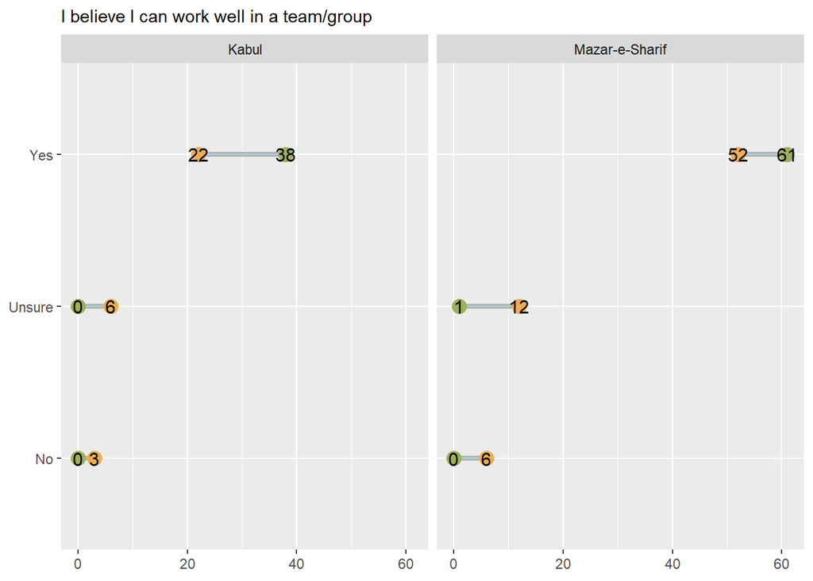

```r
Graphfunc(Teamwork.CurrYear, y="I believe I can work well in a team/group", x="PreQ.rel.freq", xend="PostQ.rel.freq")
```

### Safety in Skatepark

```r
Skatepark.Safety.CurrYear <- Countfunc(PreQ.CurrYear,PostQ.CurrYear,"How do you feel in the skatepark")
```

```
##         ID   Project.Site freq PreQ.rel.freq
## 1 Not safe          Kabul    1             1
## 2 Not safe Mazar-e-Sharif   27            19
## 3     Safe          Kabul   21            15
## 4     Safe Mazar-e-Sharif   52            36
## 5   Unsure          Kabul   22            15
## 6   Unsure Mazar-e-Sharif   21            15
##       ID   Project.Site freq PostQ.rel.freq
## 1   Safe          Kabul   43             38
## 2   Safe Mazar-e-Sharif   69             61
## 3 Unsure Mazar-e-Sharif    1              1
```

```r
Skatepark.Safety.CurrYear
```

| How do you feel in the skatepark | Project.Site | freq.PreQ | PreQ.rel.freq | freq.PostQ | PostQ.rel.freq |
| --- | --- | --- | --- | --- | --- |
| Not safe | Kabul | 1 | 1 | 0 | 0 |
| Not safe | Mazar-e-Sharif | 27 | 19 | 0 | 0 |
| Safe | Kabul | 21 | 15 | 43 | 38 |
| Safe | Mazar-e-Sharif | 52 | 36 | 69 | 61 |
| Unsure | Kabul | 22 | 15 | 0 | 0 |
| Unsure | Mazar-e-Sharif | 21 | 15 | 1 | 1 |

Statistics available only for 2018-2019. At the beginning of the year approximately 30% of the students weren’t sure about their safety in the skatepark, while a high proportion of students in Mazar-e-Sharif felt unsafe. Towards the end of the year however, all but one student felt safe in the skatepark. A remarkable improvement.

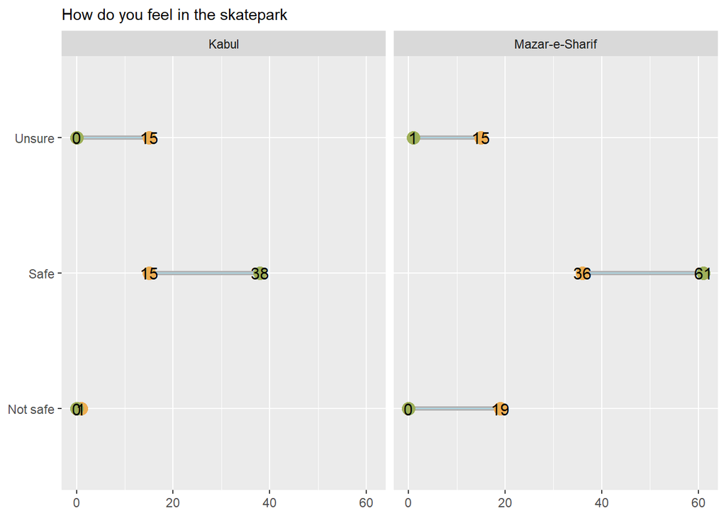

```r
Graphfunc(Skatepark.Safety.CurrYear, y="How do you feel in the skatepark", x="PreQ.rel.freq", xend="PostQ.rel.freq")
```

### Safety in classroom

```r
Classroom.Safety.CurrYear <- Countfunc(PreQ.CurrYear,PostQ.CurrYear,"How do you feel in the classroom")
```

```
##         ID   Project.Site freq PreQ.rel.freq
## 1 Not safe Mazar-e-Sharif    3             2
## 2     Safe          Kabul   41            28
## 3     Safe Mazar-e-Sharif   77            53
## 4   Unsure          Kabul    3             2
## 5   Unsure Mazar-e-Sharif   20            14
##       ID   Project.Site freq PostQ.rel.freq
## 1   Safe          Kabul   42             37
## 2   Safe Mazar-e-Sharif   70             62
## 3 Unsure          Kabul    1              1
```

```r
Classroom.Safety.CurrYear
```

| How do you feel in the classroom | Project.Site | freq.PreQ | PreQ.rel.freq | freq.PostQ | PostQ.rel.freq |
| --- | --- | --- | --- | --- | --- |
| Not safe | Mazar-e-Sharif | 3 | 2 | 0 | 0 |
| Safe | Kabul | 41 | 28 | 42 | 37 |
| Safe | Mazar-e-Sharif | 77 | 53 | 70 | 62 |
| Unsure | Kabul | 3 | 2 | 1 | 1 |
| Unsure | Mazar-e-Sharif | 20 | 14 | 0 | 0 |

Available only for 2018-2019. Most students felt safe at the start of the year, while all but one student felt safe by the end.

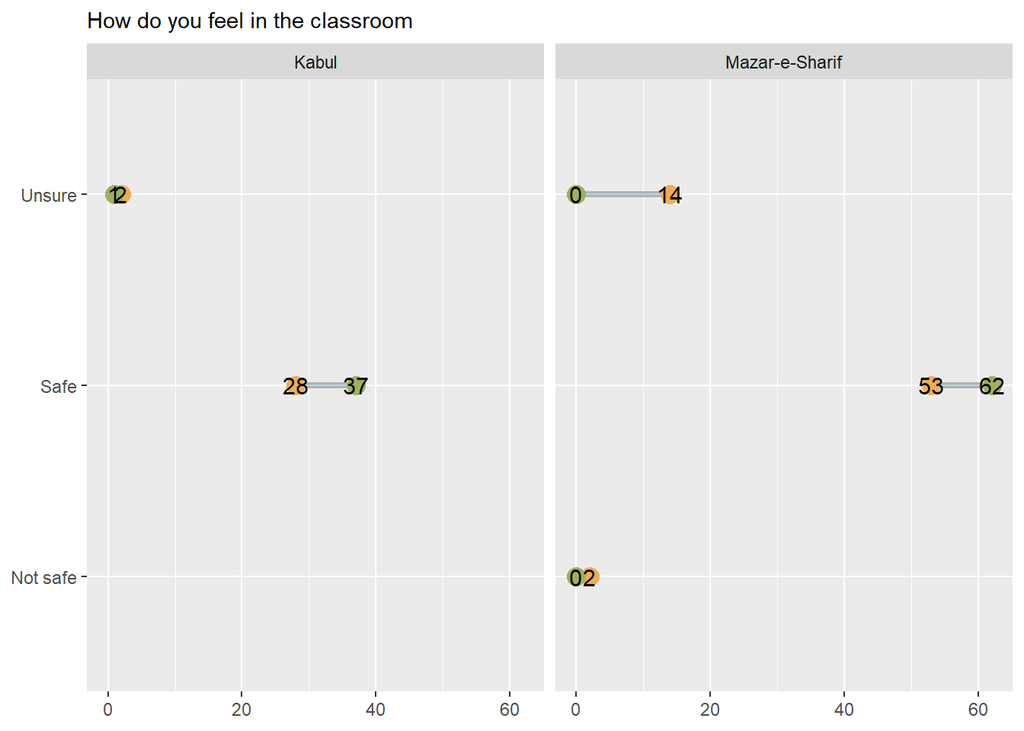

```r
Graphfunc(Classroom.Safety.CurrYear, y="How do you feel in the classroom", x="PreQ.rel.freq", xend="PostQ.rel.freq")
```

### Comfort in talking to an educator at Skateistan

```r
Educator.Safety.CurrYear <- Countfunc(PreQ.CurrYear,PostQ.CurrYear,"How do you feel talking with an Educator at Skateistan")
```

```
##         ID   Project.Site freq PreQ.rel.freq
## 1 Not safe Mazar-e-Sharif    9             6
## 2     Safe          Kabul   21            15
## 3     Safe Mazar-e-Sharif   76            53
## 4   Unsure          Kabul   23            16
## 5   Unsure Mazar-e-Sharif   15            10
##     ID   Project.Site freq PostQ.rel.freq
## 1 Safe          Kabul   43             38
## 2 Safe Mazar-e-Sharif   70             62
```

```r
Educator.Safety.CurrYear
```

| How do you feel talking with an Educator at Skateistan | Project.Site | freq.PreQ | PreQ.rel.freq | freq.PostQ | PostQ.rel.freq |
| --- | --- | --- | --- | --- | --- |
| Not safe | Mazar-e-Sharif | 9 | 6 | 0 | 0 |
| Safe | Kabul | 21 | 15 | 43 | 38 |
| Safe | Mazar-e-Sharif | 76 | 53 | 70 | 62 |
| Unsure | Kabul | 23 | 16 | 0 | 0 |
| Unsure | Mazar-e-Sharif | 15 | 10 | 0 | 0 |

Available only for 2018-2019. Schools in Kabul saw a leap in student comfort levels in this aspect, and overall, every student felt safe by the end of the year, which is a testament to the quality of the Educators.

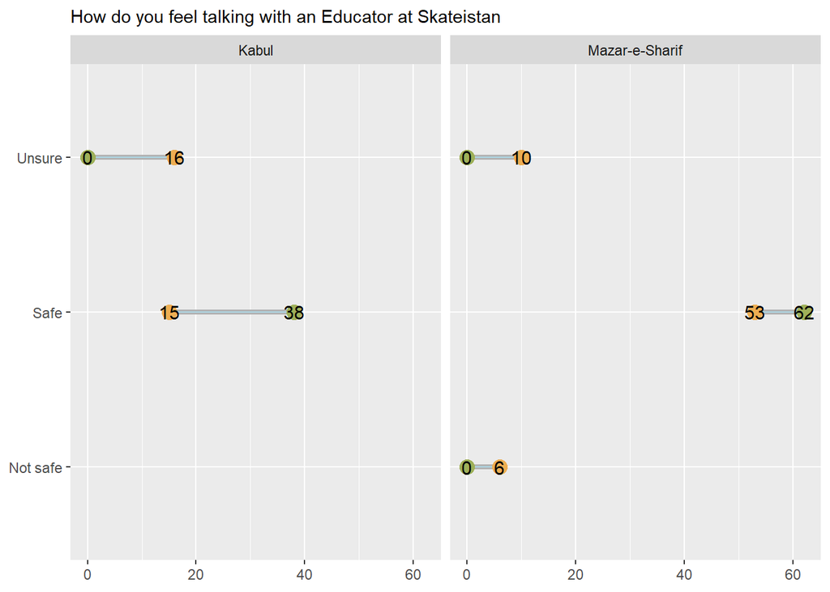

```r
Graphfunc(Educator.Safety.CurrYear, y="How do you feel talking with an Educator at Skateistan", x="PreQ.rel.freq", xend="PostQ.rel.freq")
```

### Safety learning with volunteer/youth leader

```r
Volunteer.Leader.Safety.CurrYear <- Countfunc(PreQ.CurrYear,PostQ.CurrYear,"How do you feel learning with my class volunteer / youth leader")
```

```
##         ID   Project.Site freq PreQ.rel.freq
## 1 Not safe Mazar-e-Sharif    5             3
## 2     Safe          Kabul   16            11
## 3     Safe Mazar-e-Sharif   66            46
## 4   Unsure          Kabul   28            19
## 5   Unsure Mazar-e-Sharif   29            20
##     ID   Project.Site freq PostQ.rel.freq
## 1 Safe          Kabul   43             38
## 2 Safe Mazar-e-Sharif   70             62
```

```r
Volunteer.Leader.Safety.CurrYear
```

| How do you feel learning with my class volunteer / youth leader | Project.Site | freq.PreQ | PreQ.rel.freq | freq.PostQ | PostQ.rel.freq |
| --- | --- | --- | --- | --- | --- |
| Not safe | Mazar-e-Sharif | 5 | 3 | 0 | 0 |
| Safe | Kabul | 16 | 11 | 43 | 38 |
| Safe | Mazar-e-Sharif | 66 | 46 | 70 | 62 |
| Unsure | Kabul | 28 | 19 | 0 | 0 |
| Unsure | Mazar-e-Sharif | 29 | 20 | 0 | 0 |

Available only for 2018-2019. Trends seen are similar to that as comfort in talking to Educators

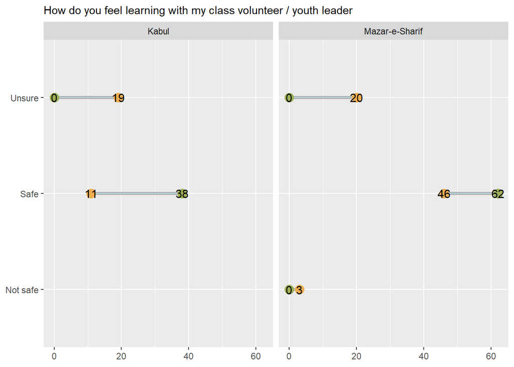

```r
Graphfunc(Volunteer.Leader.Safety.CurrYear, y="How do you feel learning with my class volunteer / youth leader", x="PreQ.rel.freq", xend="PostQ.rel.freq")
```

### Time studying

```r
Time.Studying.CurrYear <- Countfunc(PreQ.CurrYear,PostQ.CurrYear,"I believe I can spend time studying")
```

```
##       ID   Project.Site freq PreQ.rel.freq
## 1     No Mazar-e-Sharif    2             1
## 2 Unsure          Kabul   13             9
## 3 Unsure Mazar-e-Sharif   18            12
## 4    Yes          Kabul   31            22
## 5    Yes Mazar-e-Sharif   80            56
##       ID   Project.Site freq PostQ.rel.freq
## 1 Unsure          Kabul    2              2
## 2 Unsure Mazar-e-Sharif    1              1
## 3    Yes          Kabul   41             36
## 4    Yes Mazar-e-Sharif   69             61
```

```r
Time.Studying.CurrYear
```

| I believe I can spend time studying | Project.Site | freq.PreQ | PreQ.rel.freq | freq.PostQ | PostQ.rel.freq |
| --- | --- | --- | --- | --- | --- |
| No | Mazar-e-Sharif | 2 | 1 | 0 | 0 |
| Unsure | Kabul | 13 | 9 | 2 | 2 |
| Unsure | Mazar-e-Sharif | 18 | 12 | 1 | 1 |
| Yes | Kabul | 31 | 22 | 41 | 36 |
| Yes | Mazar-e-Sharif | 80 | 56 | 69 | 61 |

Available only for 2018-2019. Big improvemts seen in Kabul, with a vast majority of students believing in their ability to spend time studying

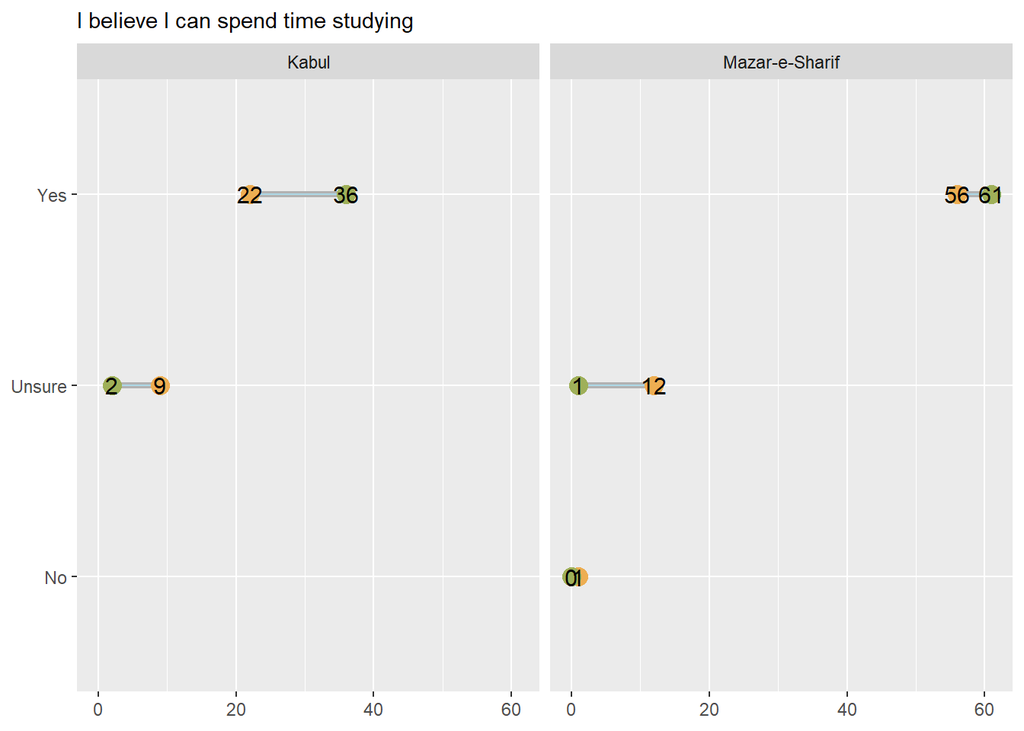

```r
Graphfunc(Time.Studying.CurrYear, y="I believe I can spend time studying", x="PreQ.rel.freq", xend="PostQ.rel.freq")
```

### Belief in doing well in school

```r
well.School.CurrYear <- Countfunc(PreQ.CurrYear,PostQ.CurrYear,"I believe I can do well in school")
```

```
##       ID   Project.Site freq PreQ.rel.freq
## 1     No Mazar-e-Sharif    8             6
## 2 Unsure          Kabul   13             9
## 3 Unsure Mazar-e-Sharif   22            15
## 4    Yes          Kabul   31            22
## 5    Yes Mazar-e-Sharif   70            49
##       ID   Project.Site freq PostQ.rel.freq
## 1     No Mazar-e-Sharif    2              2
## 2 Unsure          Kabul    1              1
## 3    Yes          Kabul   42             37
## 4    Yes Mazar-e-Sharif   68             60
```

```r
well.School.CurrYear
```

| I believe I can do well in school | Project.Site | freq.PreQ | PreQ.rel.freq | freq.PostQ | PostQ.rel.freq |
| --- | --- | --- | --- | --- | --- |
| No | Mazar-e-Sharif | 8 | 6 | 2 | 2 |
| Unsure | Kabul | 13 | 9 | 1 | 1 |
| Unsure | Mazar-e-Sharif | 22 | 15 | 0 | 0 |
| Yes | Kabul | 31 | 22 | 42 | 37 |
| Yes | Mazar-e-Sharif | 70 | 49 | 68 | 60 |

Available only for 2018-2019. 2 students in Mazar-e-Sharif and 1 in Kabul lack confidence in doing well in school, so there is a minor room for improvement. But there is still a big improvement in a vast majority of students

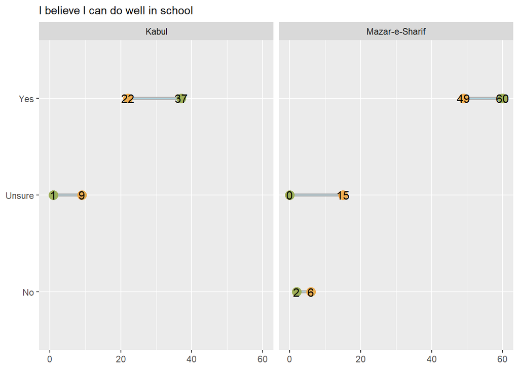

```r
Graphfunc(well.School.CurrYear, y="I believe I can do well in school", x="PreQ.rel.freq", xend="PostQ.rel.freq")
```

### New skateboard tricks

```r
Skateboard.Tricks.CurrYear <- Countfunc(PreQ.CurrYear,PostQ.CurrYear,"I believe I can learn new skateboard tricks")
```

```
##       ID   Project.Site freq PreQ.rel.freq
## 1     No          Kabul    2             1
## 2     No Mazar-e-Sharif   31            22
## 3 Unsure          Kabul   24            17
## 4 Unsure Mazar-e-Sharif   20            14
## 5    Yes          Kabul   18            12
## 6    Yes Mazar-e-Sharif   49            34
##       ID   Project.Site freq PostQ.rel.freq
## 1 Unsure          Kabul    1              1
## 2 Unsure Mazar-e-Sharif    3              3
## 3    Yes          Kabul   42             37
## 4    Yes Mazar-e-Sharif   67             59
```

```r
Skateboard.Tricks.CurrYear
```

| I believe I can learn new skateboard tricks | Project.Site | freq.PreQ | PreQ.rel.freq | freq.PostQ | PostQ.rel.freq |
| --- | --- | --- | --- | --- | --- |
| No | Kabul | 2 | 1 | 0 | 0 |
| No | Mazar-e-Sharif | 31 | 22 | 0 | 0 |
| Unsure | Kabul | 24 | 17 | 1 | 1 |
| Unsure | Mazar-e-Sharif | 20 | 14 | 3 | 3 |
| Yes | Kabul | 18 | 12 | 42 | 37 |
| Yes | Mazar-e-Sharif | 49 | 34 | 67 | 59 |

Available only for 2018-2019. Perhaps one of the proudest achievements for Skateistan staff in Afghanistan, as schools across the country see vast improvements in students ability to skateboard.

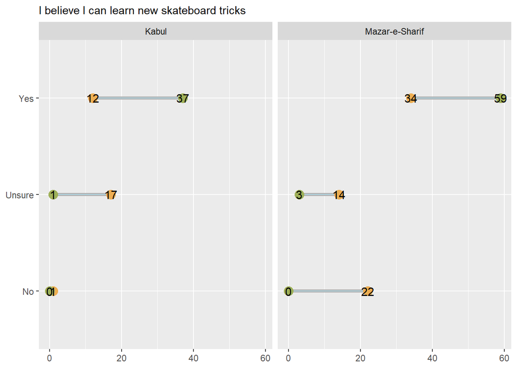

```r
Graphfunc(Skateboard.Tricks.CurrYear, y="I believe I can learn new skateboard tricks", x="PreQ.rel.freq", xend="PostQ.rel.freq")
```

### Good at skateboarding

```r
Good.Skateboarding.CurrYear <- Countfunc(PreQ.CurrYear,PostQ.CurrYear,"I am good at skateboarding")
```

```
##       ID   Project.Site freq PreQ.rel.freq
## 1     No          Kabul   19            13
## 2     No Mazar-e-Sharif   29            20
## 3 Unsure          Kabul   14            10
## 4 Unsure Mazar-e-Sharif   24            17
## 5    Yes          Kabul   11             8
## 6    Yes Mazar-e-Sharif   47            33
##       ID   Project.Site freq PostQ.rel.freq
## 1 Unsure          Kabul    1              1
## 2 Unsure Mazar-e-Sharif    7              6
## 3    Yes          Kabul   42             37
## 4    Yes Mazar-e-Sharif   63             56
```

```r
Good.Skateboarding.CurrYear
```

| I am good at skateboarding | Project.Site | freq.PreQ | PreQ.rel.freq | freq.PostQ | PostQ.rel.freq |
| --- | --- | --- | --- | --- | --- |
| No | Kabul | 19 | 13 | 0 | 0 |
| No | Mazar-e-Sharif | 29 | 20 | 0 | 0 |
| Unsure | Kabul | 14 | 10 | 1 | 1 |
| Unsure | Mazar-e-Sharif | 24 | 17 | 7 | 6 |
| Yes | Kabul | 11 | 8 | 42 | 37 |
| Yes | Mazar-e-Sharif | 47 | 33 | 63 | 56 |

Available only for 2018-2019. Similar to the previous section, vast improvement seen in students across the country

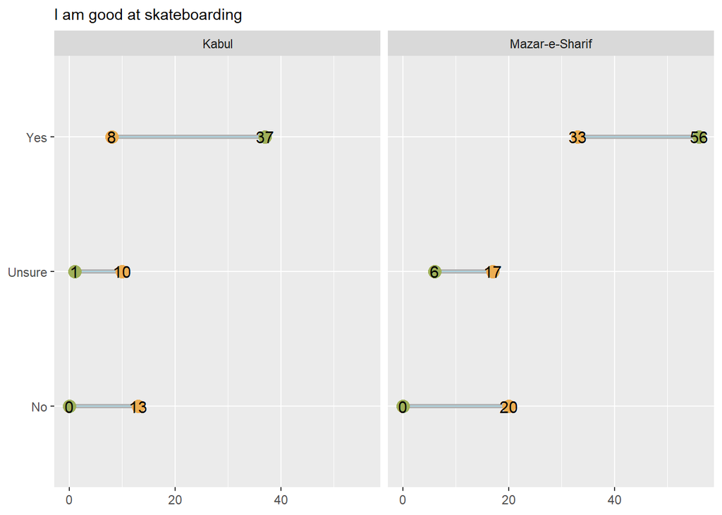

```r
Graphfunc(Good.Skateboarding.CurrYear, y="I am good at skateboarding", x="PreQ.rel.freq", xend="PostQ.rel.freq")
```

### Good at other sports is okay. Only for 2018-2019

```r
Good.Sports.CurrYear <- Countfunc(PreQ.CurrYear,PostQ.CurrYear,"I am good at other sports")
```

```
##       ID   Project.Site freq PreQ.rel.freq
## 1     No Mazar-e-Sharif   10             7
## 2 Unsure          Kabul    6             4
## 3 Unsure Mazar-e-Sharif   20            14
## 4    Yes          Kabul   38            26
## 5    Yes Mazar-e-Sharif   70            49
##       ID   Project.Site freq PostQ.rel.freq
## 1     No Mazar-e-Sharif    1              1
## 2 Unsure          Kabul    1              1
## 3 Unsure Mazar-e-Sharif    1              1
## 4    Yes          Kabul   42             37
## 5    Yes Mazar-e-Sharif   68             60
```

```r
Good.Sports.CurrYear
```

| I am good at other sports | Project.Site | freq.PreQ | PreQ.rel.freq | freq.PostQ | PostQ.rel.freq |
| --- | --- | --- | --- | --- | --- |
| No | Mazar-e-Sharif | 10 | 7 | 1 | 1 |
| Unsure | Kabul | 6 | 4 | 1 | 1 |
| Unsure | Mazar-e-Sharif | 20 | 14 | 1 | 1 |
| Yes | Kabul | 38 | 26 | 42 | 37 |
| Yes | Mazar-e-Sharif | 70 | 49 | 68 | 60 |

Available only for 2018-2019. Students are largely confident in their ability to play other sports, barring a few.

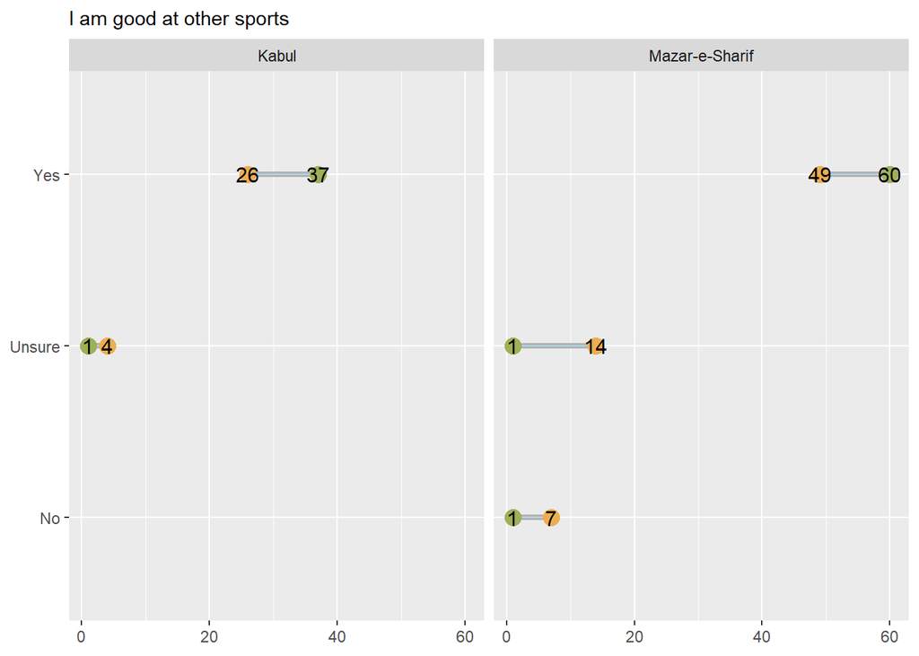

```r
Graphfunc(Good.Sports.CurrYear, y="I am good at other sports", x="PreQ.rel.freq", xend="PostQ.rel.freq")
```

### Calm and relaxed is okay. Only for 2018-2019

```r
Calm.CurrYear <- Countfunc(PreQ.CurrYear,PostQ.CurrYear,"Over the past 2-3 weeks I have felt calm and relaxed")
```

```
##       ID   Project.Site freq PreQ.rel.freq
## 1 Unsure          Kabul    8             6
## 2 Unsure Mazar-e-Sharif   21            15
## 3    Yes          Kabul   36            25
## 4    Yes Mazar-e-Sharif   79            55
##    ID   Project.Site freq PostQ.rel.freq
## 1 Yes          Kabul   43             38
## 2 Yes Mazar-e-Sharif   70             62
```

```r
Calm.CurrYear
```

| Over the past 2-3 weeks I have felt calm and relaxed | Project.Site | freq.PreQ | PreQ.rel.freq | freq.PostQ | PostQ.rel.freq |
| --- | --- | --- | --- | --- | --- |
| Unsure | Kabul | 8 | 6 | 0 | 0 |
| Unsure | Mazar-e-Sharif | 21 | 15 | 0 | 0 |
| Yes | Kabul | 36 | 25 | 43 | 38 |
| Yes | Mazar-e-Sharif | 79 | 55 | 70 | 62 |

Available only for 2018-2019. Every student had a feeling of calm and relaxation in the time preceding to filling the questionnaire, which jumps up from 80% at the start of the year.

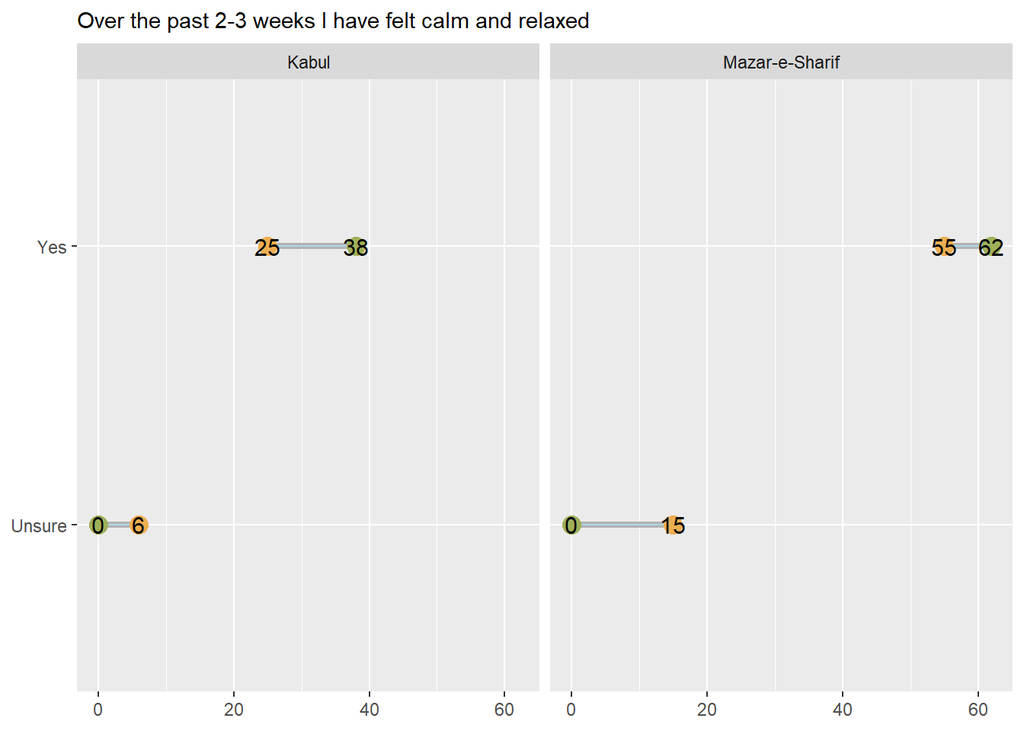

```r
Graphfunc(Calm.CurrYear, y="Over the past 2-3 weeks I have felt calm and relaxed", x="PreQ.rel.freq", xend="PostQ.rel.freq")
```

### Fresh and rested is okay. Only for 2018-2019

```r
Fresh.Rested.CurrYear <- Countfunc(PreQ.CurrYear,PostQ.CurrYear,"Over the past 2-3 weeks I wake up feeling fresh and rested")
```

```
##       ID   Project.Site freq PreQ.rel.freq
## 1     No          Kabul    1             1
## 2     No Mazar-e-Sharif    1             1
## 3 Unsure          Kabul   19            13
## 4 Unsure Mazar-e-Sharif   26            18
## 5    Yes          Kabul   24            17
## 6    Yes Mazar-e-Sharif   73            51
##       ID   Project.Site freq PostQ.rel.freq
## 1 Unsure          Kabul    1              1
## 2    Yes          Kabul   42             37
## 3    Yes Mazar-e-Sharif   70             62
```

```r
Fresh.Rested.CurrYear
```

| Over the past 2-3 weeks I wake up feeling fresh and rested | Project.Site | freq.PreQ | PreQ.rel.freq | freq.PostQ | PostQ.rel.freq |
| --- | --- | --- | --- | --- | --- |
| No | Kabul | 1 | 1 | 0 | 0 |
| No | Mazar-e-Sharif | 1 | 1 | 0 | 0 |
| Unsure | Kabul | 19 | 13 | 1 | 1 |
| Unsure | Mazar-e-Sharif | 26 | 18 | 0 | 0 |
| Yes | Kabul | 24 | 17 | 42 | 37 |
| Yes | Mazar-e-Sharif | 73 | 51 | 70 | 62 |

Available only for 2018-2019. Almost every student had a feeling of being fresh and rested in the time preceding to filling the questionnaire, which jumps up from 68% at the start of the year.

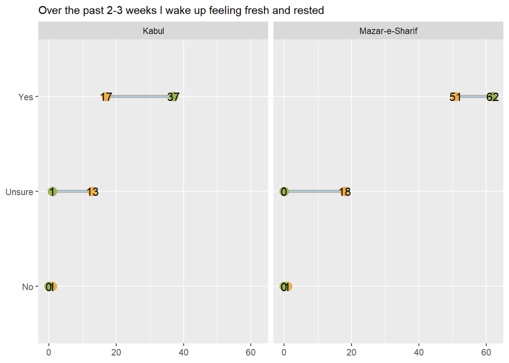

```r
Graphfunc(Fresh.Rested.CurrYear, y="Over the past 2-3 weeks I wake up feeling fresh and rested", x="PreQ.rel.freq", xend="PostQ.rel.freq")
```

### My daily life has been filled with things that interest me

```r
Life.Interest.CurrYear <- Countfunc(PreQ.CurrYear,PostQ.CurrYear,"Over the past 2-3 weeks My daily life has been filled with things that interest me")
```

```
##       ID   Project.Site freq PreQ.rel.freq
## 1     No          Kabul    6             4
## 2     No Mazar-e-Sharif    6             4
## 3 Unsure          Kabul   17            12
## 4 Unsure Mazar-e-Sharif   22            15
## 5    Yes          Kabul   21            15
## 6    Yes Mazar-e-Sharif   72            50
##       ID   Project.Site freq PostQ.rel.freq
## 1 Unsure          Kabul    2              2
## 2    Yes          Kabul   41             36
## 3    Yes Mazar-e-Sharif   70             62
```

```r
Life.Interest.CurrYear
```

| Over the past 2-3 weeks My daily life has been filled with things that interest me | Project.Site | freq.PreQ | PreQ.rel.freq | freq.PostQ | PostQ.rel.freq |
| --- | --- | --- | --- | --- | --- |
| No | Kabul | 6 | 4 | 0 | 0 |
| No | Mazar-e-Sharif | 6 | 4 | 0 | 0 |
| Unsure | Kabul | 17 | 12 | 2 | 2 |
| Unsure | Mazar-e-Sharif | 22 | 15 | 0 | 0 |
| Yes | Kabul | 21 | 15 | 41 | 36 |
| Yes | Mazar-e-Sharif | 72 | 50 | 70 | 62 |

Available only for 2018-2019. Barring two students in Kabul, every student had an optimistic view on their daily life in the time preceding to filling the questionnaire, which jumps up from just 65% at the start of the year.

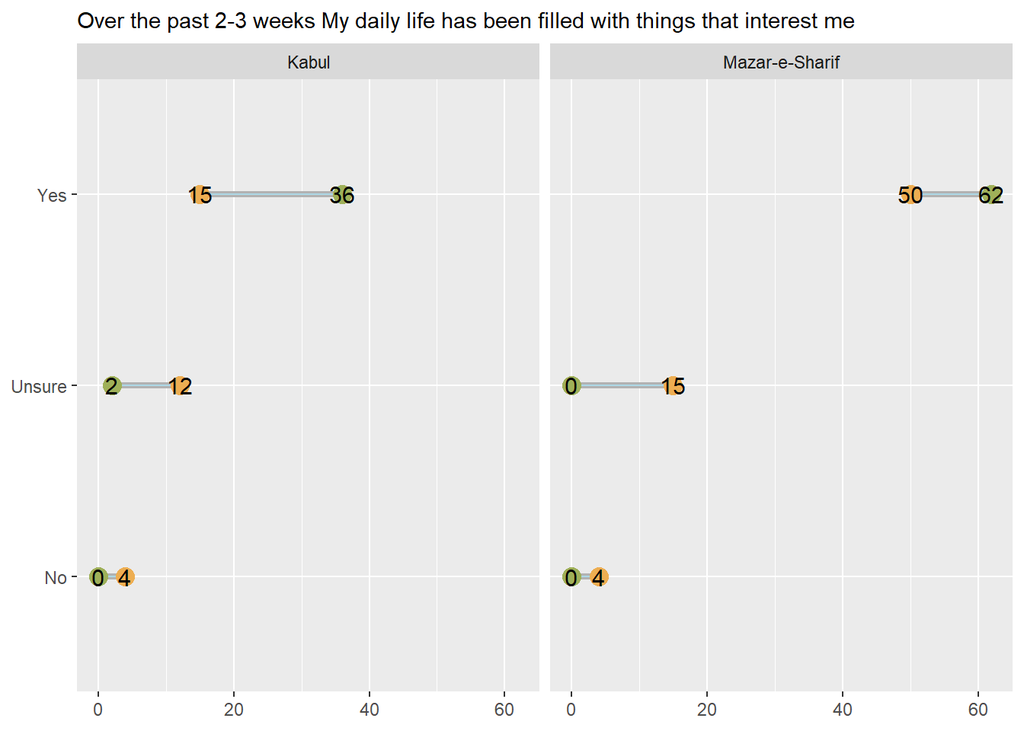

```r
Graphfunc(Life.Interest.CurrYear, "Over the past 2-3 weeks My daily life has been filled with things that interest me", x="PreQ.rel.freq", xend="PostQ.rel.freq")
```

### Gender

```r
Gender.CurrYear <- Countfunc(PreQ.CurrYear,PostQ.CurrYear,"Gender")
```

```
##       ID   Project.Site freq PreQ.rel.freq
## 1 Female          Kabul   23            16
## 2 Female Mazar-e-Sharif   36            25
## 3   Male          Kabul   21            15
## 4   Male Mazar-e-Sharif   64            44
##       ID   Project.Site freq PostQ.rel.freq
## 1 Female          Kabul   21             19
## 2 Female Mazar-e-Sharif   22             19
## 3   Male          Kabul   22             19
## 4   Male Mazar-e-Sharif   48             42
```

```r
Gender.CurrYear
```

| Gender | Project.Site | freq.PreQ | PreQ.rel.freq | freq.PostQ | PostQ.rel.freq |
| --- | --- | --- | --- | --- | --- |
| Female | Kabul | 23 | 16 | 21 | 19 |
| Female | Mazar-e-Sharif | 36 | 25 | 22 | 19 |
| Male | Kabul | 21 | 15 | 22 | 19 |
| Male | Mazar-e-Sharif | 64 | 44 | 48 | 42 |

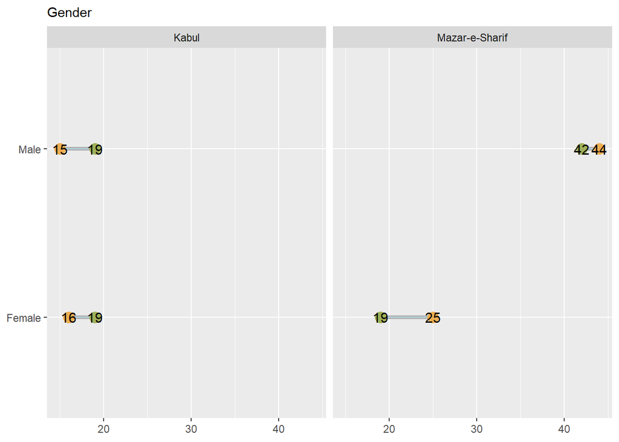

```r
Graphfunc(Gender.CurrYear, "Gender", x="PreQ.rel.freq", xend="PostQ.rel.freq")
```

### Safety at Skateistan

```r
Safety.PrevYear <- Countfunc(PreQ.PrevYear,PostQ.PrevYear,"How safe do you feel at Skateistan?")
```

```
##          ID Project.Site freq PreQ.rel.freq
## 1                  Mazar    1             1
## 2      Safe        Kabul   15            17
## 3      Safe        Mazar   44            49
## 4 Very safe        Kabul   24            27
## 5 Very safe        Mazar    5             6
##          ID Project.Site freq PostQ.rel.freq
## 1                  Kabul    2              2
## 2      Safe        Kabul   15             17
## 3      Safe        Mazar    2              2
## 4 Very safe        Kabul   25             29
## 5 Very safe        Mazar   43             49
```

```r
Safety.PrevYear
```

| How safe do you feel at Skateistan? | Project.Site | freq.PreQ | PreQ.rel.freq | freq.PostQ | PostQ.rel.freq |
| --- | --- | --- | --- | --- | --- |
|  | Kabul | 0 | 0 | 2 | 2 |
|  | Mazar | 1 | 1 | 0 | 0 |
| Safe | Kabul | 15 | 17 | 15 | 17 |
| Safe | Mazar | 44 | 49 | 2 | 2 |
| Very safe | Kabul | 24 | 27 | 25 | 29 |
| Very safe | Mazar | 5 | 6 | 43 | 49 |

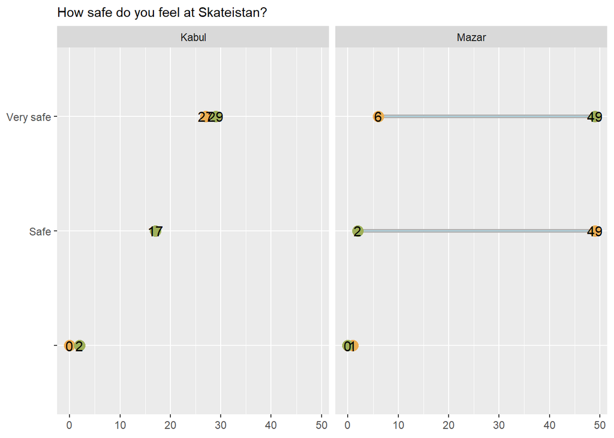

```r
Graphfunc(Safety.PrevYear, "How safe do you feel at Skateistan?", x="PreQ.rel.freq", xend="PostQ.rel.freq")
```

```r
Safety.CurrYear <- Countfunc(PreQ.CurrYear,PostQ.CurrYear,"How do you feel traveling to/from Skateistan")
```

```
##         ID   Project.Site freq PreQ.rel.freq
## 1 Not safe Mazar-e-Sharif    3             2
## 2     Safe          Kabul   41            28
## 3     Safe Mazar-e-Sharif   79            55
## 4   Unsure          Kabul    3             2
## 5   Unsure Mazar-e-Sharif   18            12
##     ID   Project.Site freq PostQ.rel.freq
## 1 Safe          Kabul   43             38
## 2 Safe Mazar-e-Sharif   70             62
```

```r
Safety.CurrYear
```

| How do you feel traveling to/from Skateistan | Project.Site | freq.PreQ | PreQ.rel.freq | freq.PostQ | PostQ.rel.freq |
| --- | --- | --- | --- | --- | --- |
| Not safe | Mazar-e-Sharif | 3 | 2 | 0 | 0 |
| Safe | Kabul | 41 | 28 | 43 | 38 |
| Safe | Mazar-e-Sharif | 79 | 55 | 70 | 62 |
| Unsure | Kabul | 3 | 2 | 0 | 0 |
| Unsure | Mazar-e-Sharif | 18 | 12 | 0 | 0 |

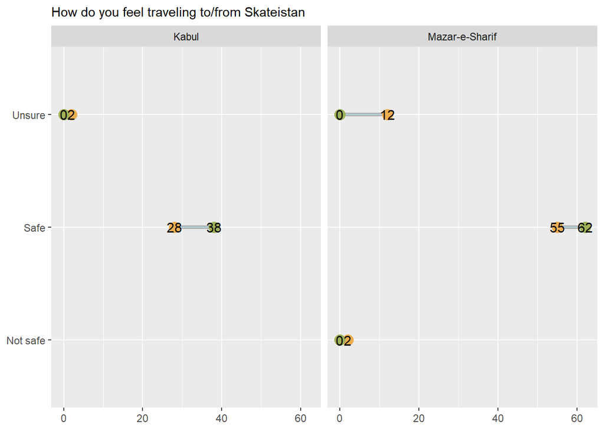

```r
Graphfunc(Safety.CurrYear, "How do you feel traveling to/from Skateistan", x="PreQ.rel.freq", xend="PostQ.rel.freq")
```

### BTS class experience

```r
BTS.Experience.PrevYear <- Countfunc(PreQ.PrevYear,PostQ.PrevYear,"My experience coming to BTS classes has been")
```

```
##          ID Project.Site freq PreQ.rel.freq
## 1                  Kabul    1             1
## 2      Good        Kabul   36            40
## 3      Good        Mazar   42            47
## 4   Neutral        Mazar    1             1
## 5 Very Good        Kabul    2             2
## 6 Very Good        Mazar    7             8
##          ID Project.Site freq PostQ.rel.freq
## 1      Good        Kabul   17             20
## 2 Very Good        Kabul   25             29
## 3 Very Good        Mazar   45             52
```

```r
BTS.Experience.PrevYear
```

| My experience coming to BTS classes has been | Project.Site | freq.PreQ | PreQ.rel.freq | freq.PostQ | PostQ.rel.freq |
| --- | --- | --- | --- | --- | --- |
|  | Kabul | 1 | 1 | 0 | 0 |
| Good | Kabul | 36 | 40 | 17 | 20 |
| Good | Mazar | 42 | 47 | 0 | 0 |
| Neutral | Mazar | 1 | 1 | 0 | 0 |
| Very Good | Kabul | 2 | 2 | 25 | 29 |
| Very Good | Mazar | 7 | 8 | 45 | 52 |

Available only for 2017-2018. At the start of the year, about 87% thought it was good and 10% thought it was very good, while at the end of the year, 81% thought it was very good while the rest thought it was good. It shows an improvement in quality over the year.

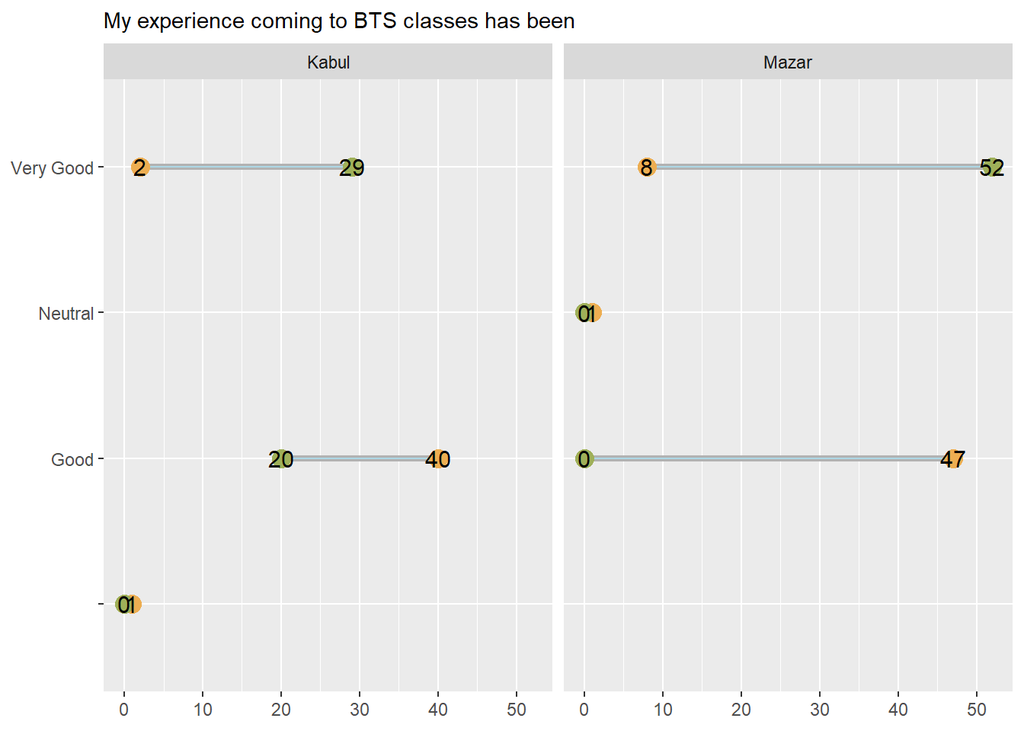

```r
Graphfunc(BTS.Experience.PrevYear, "My experience coming to BTS classes has been", x="PreQ.rel.freq", xend="PostQ.rel.freq")
```

### To be seen if confidence can be matched with general liking of oneself

```r
Confidence.PrevYear <- Countfunc(PreQ.PrevYear,PostQ.PrevYear,"Confidence since joining the program has")
```

```
##                     ID Project.Site freq PreQ.rel.freq
## 1 Gone up a little bit        Kabul   18            20
## 2 Gone up a little bit        Mazar   31            35
## 3        Gone up a lot        Kabul   19            21
## 4        Gone up a lot        Mazar    9            10
## 5             Not sure        Mazar    2             2
## 6      Stayed the same        Kabul    2             2
## 7      Stayed the same        Mazar    8             9
##                     ID Project.Site freq PostQ.rel.freq
## 1                             Kabul    1              1
## 2 Gone up a little bit        Kabul   17             20
## 3 Gone up a little bit        Mazar    6              7
## 4        Gone up a lot        Kabul   24             28
## 5        Gone up a lot        Mazar   39             45
```

```r
Confidence.PrevYear
```

| Confidence since joining the program has | Project.Site | freq.PreQ | PreQ.rel.freq | freq.PostQ | PostQ.rel.freq |
| --- | --- | --- | --- | --- | --- |
|  | Kabul | 0 | 0 | 1 | 1 |
| Gone up a little bit | Kabul | 18 | 20 | 17 | 20 |
| Gone up a little bit | Mazar | 31 | 35 | 6 | 7 |
| Gone up a lot | Kabul | 19 | 21 | 24 | 28 |
| Gone up a lot | Mazar | 9 | 10 | 39 | 45 |
| Not sure | Mazar | 2 | 2 | 0 | 0 |
| Stayed the same | Kabul | 2 | 2 | 0 | 0 |
| Stayed the same | Mazar | 8 | 9 | 0 | 0 |

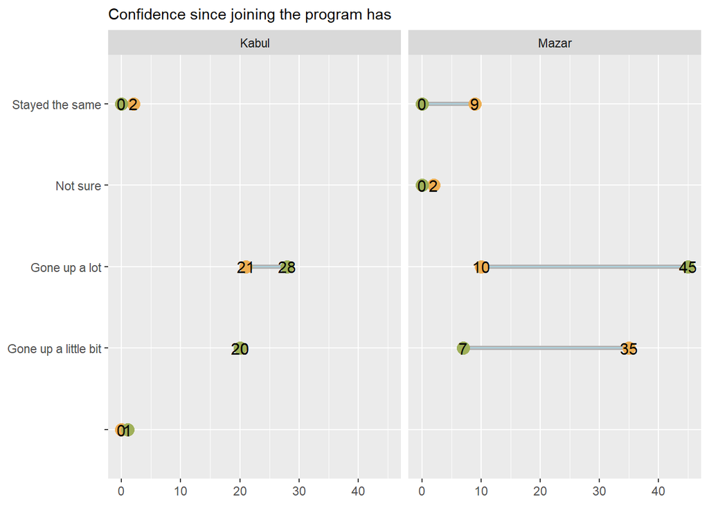

```r
Graphfunc(Confidence.PrevYear, "Confidence since joining the program has", x="PreQ.rel.freq", xend="PostQ.rel.freq")
```

### Learning usefull skills from BTS classes

This metric has also been measured over two years

```r
Learn.Skills.PrevYear <- Countfunc(PreQ.PrevYear,PostQ.PrevYear,"I have learned a lot of useful skills and lessons since coming to BTS classes at Skateistan")
```

```
##               ID Project.Site freq PreQ.rel.freq
## 1                       Mazar    1             1
## 2          Agree        Kabul   24            27
## 3          Agree        Mazar   43            48
## 4        Neutral        Kabul    2             2
## 5        Neutral        Mazar    6             7
## 6 Strongly Agree        Kabul   13            15
##               ID Project.Site freq PostQ.rel.freq
## 1                       Kabul    5              6
## 2                       Mazar    1              1
## 3          Agree        Kabul   12             14
## 4          Agree        Mazar    2              2
## 5        Neutral        Kabul    1              1
## 6 Strongly Agree        Kabul   24             28
## 7 Strongly Agree        Mazar   42             48
```

```r
Learn.Skills.PrevYear
```

| I have learned a lot of useful skills and lessons since coming to BTS classes at Skateistan | Project.Site | freq.PreQ | PreQ.rel.freq | freq.PostQ | PostQ.rel.freq |
| --- | --- | --- | --- | --- | --- |
|  | Kabul | 0 | 0 | 5 | 6 |
|  | Mazar | 1 | 1 | 1 | 1 |
| Agree | Kabul | 24 | 27 | 12 | 14 |
| Agree | Mazar | 43 | 48 | 2 | 2 |
| Neutral | Kabul | 2 | 2 | 1 | 1 |
| Neutral | Mazar | 6 | 7 | 0 | 0 |
| Strongly Agree | Kabul | 13 | 15 | 24 | 28 |
| Strongly Agree | Mazar | 0 | 0 | 42 | 48 |

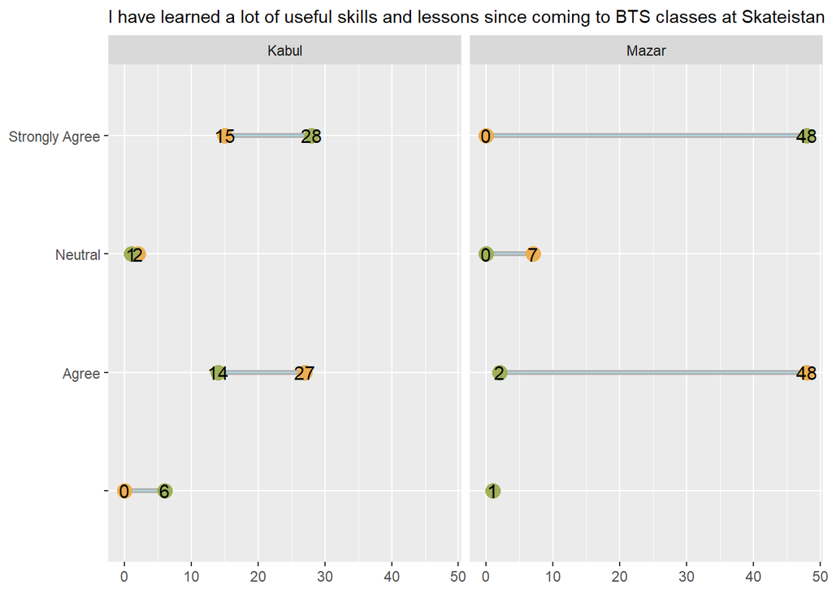

```r
Graphfunc(Learn.Skills.PrevYear, "I have learned a lot of useful skills and lessons since coming to BTS classes at Skateistan", x="PreQ.rel.freq", xend="PostQ.rel.freq")
```

```r
Friends.PrevYear <- Countfunc(PreQ.PrevYear,PostQ.PrevYear,"Friends made at Skateistan")
```

```
##                              ID Project.Site freq PreQ.rel.freq
## 1                            No        Kabul    2             2
## 2                            No        Mazar    1             1
## 3                      Not sure        Kabul    1             1
## 4                      Not sure        Mazar    5             6
## 5 Yes, more than one new friend        Kabul   30            34
## 6 Yes, more than one new friend        Mazar   33            37
## 7           Yes, one new friend        Kabul    6             7
## 8           Yes, one new friend        Mazar   11            12
##                              ID Project.Site freq PostQ.rel.freq
## 1 Yes, more than one new friend        Kabul   42             48
## 2 Yes, more than one new friend        Mazar   40             46
## 3           Yes, one new friend        Mazar    5              6
```

```r
Friends.PrevYear
```

| Friends made at Skateistan | Project.Site | freq.PreQ | PreQ.rel.freq | freq.PostQ | PostQ.rel.freq |
| --- | --- | --- | --- | --- | --- |
| No | Kabul | 2 | 2 | 0 | 0 |
| No | Mazar | 1 | 1 | 0 | 0 |
| Not sure | Kabul | 1 | 1 | 0 | 0 |
| Not sure | Mazar | 5 | 6 | 0 | 0 |
| Yes, more than one new friend | Kabul | 30 | 34 | 42 | 48 |
| Yes, more than one new friend | Mazar | 33 | 37 | 40 | 46 |
| Yes, one new friend | Kabul | 6 | 7 | 0 | 0 |
| Yes, one new friend | Mazar | 11 | 12 | 5 | 6 |

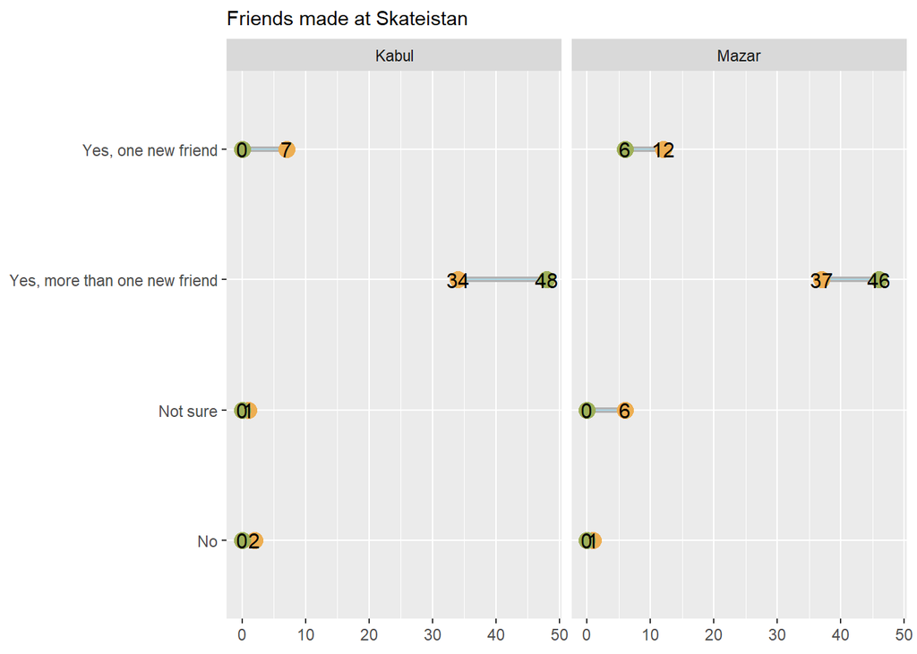

```r
Graphfunc(Friends.PrevYear, "Friends made at Skateistan", x="PreQ.rel.freq", xend="PostQ.rel.freq")
```

### Reading and Writing

Over two years, a strong improvement is seen, driven by the improvement in Mazar-e-Sharif over the course of 2017-2018. By the end of the 2018-2019 school year, every student believed in their reading abilities while an incredible 92% believed in their writing skills

```r
Reading.Writing.PrevYear <- Countfunc(PreQ.PrevYear,PostQ.PrevYear,"I am good at reading and writing")
```

```
##                ID Project.Site freq PreQ.rel.freq
## 1                        Kabul    1             1
## 2                        Mazar    1             1
## 3           Agree        Kabul   29            33
## 4           Agree        Mazar   35            39
## 5        Disagree        Kabul    1             1
## 6        Disagree        Mazar    2             2
## 7         Neutral        Kabul    3             3
## 8         Neutral        Mazar    9            10
## 9        Not sure        Mazar    1             1
## 10 Strongly Agree        Kabul    5             6
## 11 Strongly Agree        Mazar    2             2
##               ID Project.Site freq PostQ.rel.freq
## 1                       Kabul    2              2
## 2          Agree        Kabul   25             29
## 3          Agree        Mazar    4              5
## 4        Neutral        Kabul    6              7
## 5        Neutral        Mazar    3              3
## 6 Strongly Agree        Kabul    9             10
## 7 Strongly Agree        Mazar   38             44
```

```r
Reading.Writing.PrevYear
```

| I am good at reading and writing | Project.Site | freq.PreQ | PreQ.rel.freq | freq.PostQ | PostQ.rel.freq |
| --- | --- | --- | --- | --- | --- |
|  | Kabul | 1 | 1 | 2 | 2 |
|  | Mazar | 1 | 1 | 0 | 0 |
| Agree | Kabul | 29 | 33 | 25 | 29 |
| Agree | Mazar | 35 | 39 | 4 | 5 |
| Disagree | Kabul | 1 | 1 | 0 | 0 |
| Disagree | Mazar | 2 | 2 | 0 | 0 |
| Neutral | Kabul | 3 | 3 | 6 | 7 |
| Neutral | Mazar | 9 | 10 | 3 | 3 |
| Not sure | Mazar | 1 | 1 | 0 | 0 |
| Strongly Agree | Kabul | 5 | 6 | 9 | 10 |

[output cut: 1 more lines]

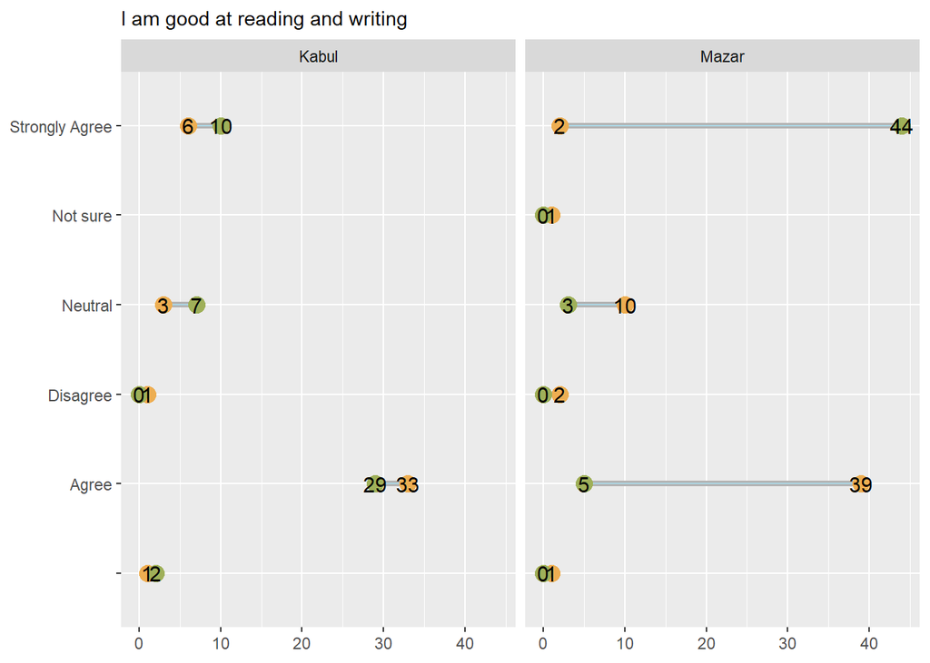

```r
Graphfunc(Reading.Writing.PrevYear, "I am good at reading and writing", x="PreQ.rel.freq", xend="PostQ.rel.freq")
```

```r
Reading.CurrYear <- Countfunc(PreQ.CurrYear,PostQ.CurrYear,"I am good at reading")
```

```
##       ID   Project.Site freq PreQ.rel.freq
## 1     No          Kabul    8             6
## 2     No Mazar-e-Sharif   22            15
## 3 Unsure          Kabul    9             6
## 4 Unsure Mazar-e-Sharif   15            10
## 5    Yes          Kabul   27            19
## 6    Yes Mazar-e-Sharif   63            44
##    ID   Project.Site freq PostQ.rel.freq
## 1 Yes          Kabul   43             38
## 2 Yes Mazar-e-Sharif   70             62
```

```r
Reading.CurrYear
```

| I am good at reading | Project.Site | freq.PreQ | PreQ.rel.freq | freq.PostQ | PostQ.rel.freq |
| --- | --- | --- | --- | --- | --- |
| No | Kabul | 8 | 6 | 0 | 0 |
| No | Mazar-e-Sharif | 22 | 15 | 0 | 0 |
| Unsure | Kabul | 9 | 6 | 0 | 0 |
| Unsure | Mazar-e-Sharif | 15 | 10 | 0 | 0 |
| Yes | Kabul | 27 | 19 | 43 | 38 |
| Yes | Mazar-e-Sharif | 63 | 44 | 70 | 62 |

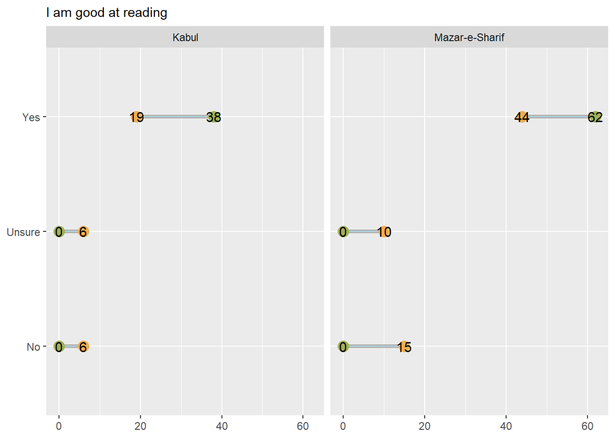

```r
Graphfunc(Reading.CurrYear, "I am good at reading", x="PreQ.rel.freq", xend="PostQ.rel.freq")
```

```r
Writing.CurrYear <- Countfunc(PreQ.CurrYear,PostQ.CurrYear,"I am good at writing")
```

```
##       ID   Project.Site freq PreQ.rel.freq
## 1     No          Kabul   13             9
## 2     No Mazar-e-Sharif   22            15
## 3 Unsure          Kabul    8             6
## 4 Unsure Mazar-e-Sharif   22            15
## 5    Yes          Kabul   23            16
## 6    Yes Mazar-e-Sharif   56            39
##       ID   Project.Site freq PostQ.rel.freq
## 1 Unsure          Kabul    4              4
## 2 Unsure Mazar-e-Sharif    6              5
## 3    Yes          Kabul   39             35
## 4    Yes Mazar-e-Sharif   64             57
```

```r
Writing.CurrYear
```

| I am good at writing | Project.Site | freq.PreQ | PreQ.rel.freq | freq.PostQ | PostQ.rel.freq |
| --- | --- | --- | --- | --- | --- |
| No | Kabul | 13 | 9 | 0 | 0 |
| No | Mazar-e-Sharif | 22 | 15 | 0 | 0 |
| Unsure | Kabul | 8 | 6 | 4 | 4 |
| Unsure | Mazar-e-Sharif | 22 | 15 | 6 | 5 |
| Yes | Kabul | 23 | 16 | 39 | 35 |
| Yes | Mazar-e-Sharif | 56 | 39 | 64 | 57 |

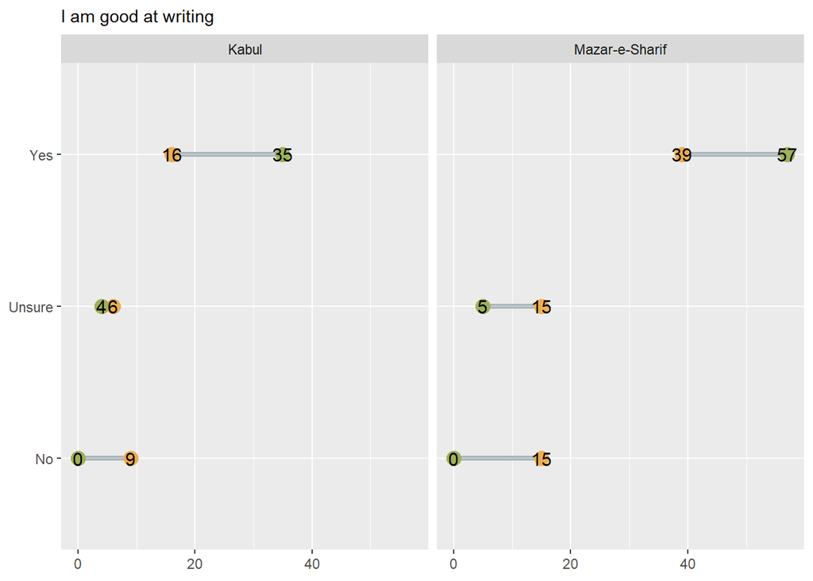

```r
Graphfunc(Writing.CurrYear, "I am good at writing", x="PreQ.rel.freq", xend="PostQ.rel.freq")
```

```r
Math.CurrYear <- Countfunc(PreQ.CurrYear,PostQ.CurrYear,"I am good at math")
```

```
##       ID   Project.Site freq PreQ.rel.freq
## 1     No          Kabul   11             8
## 2     No Mazar-e-Sharif   21            15
## 3 Unsure          Kabul   14            10
## 4 Unsure Mazar-e-Sharif   29            20
## 5    Yes          Kabul   19            13
## 6    Yes Mazar-e-Sharif   50            35
##       ID   Project.Site freq PostQ.rel.freq
## 1 Unsure Mazar-e-Sharif    7              6
## 2    Yes          Kabul   43             38
## 3    Yes Mazar-e-Sharif   63             56
```

```r
Math.CurrYear
```

| I am good at math | Project.Site | freq.PreQ | PreQ.rel.freq | freq.PostQ | PostQ.rel.freq |
| --- | --- | --- | --- | --- | --- |
| No | Kabul | 11 | 8 | 0 | 0 |
| No | Mazar-e-Sharif | 21 | 15 | 0 | 0 |
| Unsure | Kabul | 14 | 10 | 0 | 0 |
| Unsure | Mazar-e-Sharif | 29 | 20 | 7 | 6 |
| Yes | Kabul | 19 | 13 | 43 | 38 |
| Yes | Mazar-e-Sharif | 50 | 35 | 63 | 56 |

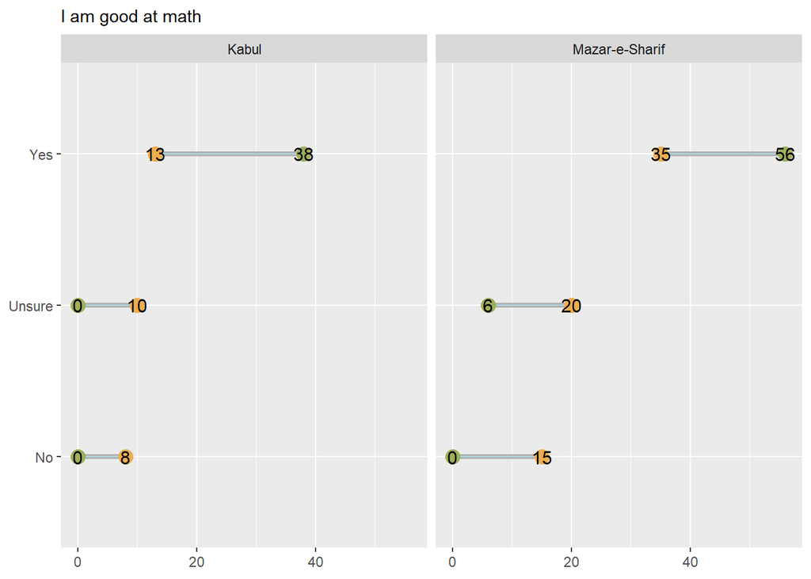

```r
Graphfunc(Math.CurrYear, "I am good at math", x="PreQ.rel.freq", xend="PostQ.rel.freq")
```

### Work history

```r
Work.PrevYear <- Countfunc(PreQ.PrevYear,PostQ.PrevYear,"Tell us about your work history")
```

```
##                                                             ID
## 1     I did not work before joining Skateistan but do work now
## 2                                          I have never worked
## 3                                          I have never worked
## 4            I worked before joining Skateistan and still work
## 5            I worked before joining Skateistan and still work
## 6 I worked before joining Skateistan but I do not work anymore
## 7 I worked before joining Skateistan but I do not work anymore
##   Project.Site freq PreQ.rel.freq
## 1        Mazar    3             3
## 2        Kabul   17            19
## 3        Mazar   26            29
## 4        Kabul   15            17
## 5        Mazar   19            21
## 6        Kabul    7             8
## 7        Mazar    2             2
##                                                             ID
## 1                                          I have never worked
## 2                                          I have never worked
## 3            I worked before joining Skateistan and still work
## 4            I worked before joining Skateistan and still work
## 5 I worked before joining Skateistan but I do not work anymore
## 6 I worked before joining Skateistan but I do not work anymore
##   Project.Site freq PostQ.rel.freq
## 1        Kabul   19             22
## 2        Mazar   29             33
## 3        Kabul   14             16
## 4        Mazar   11             13
## 5        Kabul    9             10
## 6        Mazar    5              6
```

```r
Work.PrevYear
```

| Tell us about your work history | Project.Site | freq.PreQ | PreQ.rel.freq | freq.PostQ | PostQ.rel.freq |
| --- | --- | --- | --- | --- | --- |
| I did not work before joining Skateistan but do work now | Mazar | 3 | 3 | 0 | 0 |
| I have never worked | Kabul | 17 | 19 | 19 | 22 |
| I have never worked | Mazar | 26 | 29 | 29 | 33 |
| I worked before joining Skateistan and still work | Kabul | 15 | 17 | 14 | 16 |
| I worked before joining Skateistan and still work | Mazar | 19 | 21 | 11 | 13 |
| I worked before joining Skateistan but I do not work anymore | Kabul | 7 | 8 | 9 | 10 |
| I worked before joining Skateistan but I do not work anymore | Mazar | 2 | 2 | 5 | 6 |

Available only for 2017-2018. Joining Skateistan helps marginally improve the awareness of education to the family of students, as the proportion of students who continued to work alongside attending Skateistan lessons dropped from 38% to 29%, while 16% stopped working after joining, as opposed to 10% at the start of the 2017 school year. Meanwhile, no student started working after attending Skateistan classes.

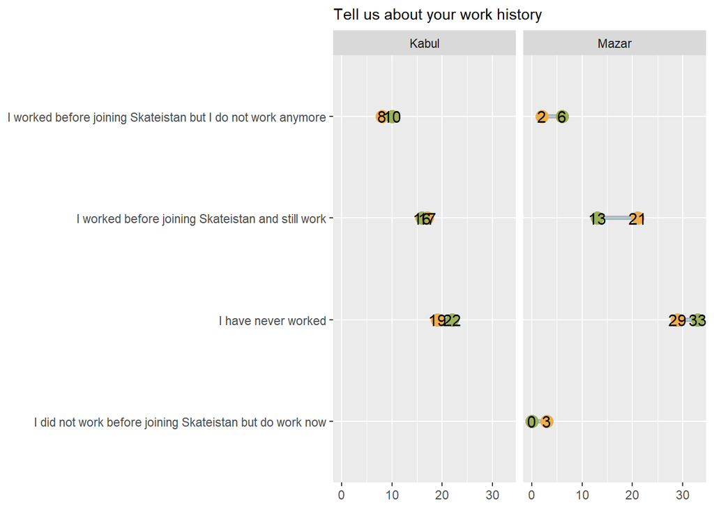

```r
Graphfunc(Work.PrevYear, "Tell us about your work history", x="PreQ.rel.freq", xend="PostQ.rel.freq")
```

```r
Education.CurrYear <- Countfunc(PreQ.CurrYear,PostQ.CurrYear,"My parents/family want me to complete my education until")
```

```
##                              ID   Project.Site freq PreQ.rel.freq
## 1 Finish school before grade 12          Kabul    2             1
## 2 Finish school before grade 12 Mazar-e-Sharif   11             8
## 3                      Grade 12          Kabul   20            14
## 4                      Grade 12 Mazar-e-Sharif   57            40
## 5                      Not Sure          Kabul    4             3
## 6                      Not Sure Mazar-e-Sharif    3             2
## 7          University or higher          Kabul   18            12
## 8          University or higher Mazar-e-Sharif   28            19
## 9                        Unsure Mazar-e-Sharif    1             1
##                                                                    ID
## 1                                                    English language
## 2                                              High School (Grade 12)
## 3                                              High School (Grade 12)
## 4                                                       learn english
```

[output cut: 19 more lines]

```r
Education.CurrYear
```

| My parents/family want me to complete my education until | Project.Site | freq.PreQ | PreQ.rel.freq | freq.PostQ | PostQ.rel.freq |
| --- | --- | --- | --- | --- | --- |
| English language | Kabul | 0 | 0 | 1 | 1 |
| Finish school before grade 12 | Kabul | 2 | 1 | 0 | 0 |
| Finish school before grade 12 | Mazar-e-Sharif | 11 | 8 | 0 | 0 |
| Grade 12 | Kabul | 20 | 14 | 0 | 0 |
| Grade 12 | Mazar-e-Sharif | 57 | 40 | 0 | 0 |
| High School (Grade 12) | Kabul | 0 | 0 | 7 | 6 |
| High School (Grade 12) | Mazar-e-Sharif | 0 | 0 | 3 | 3 |
| learn english | Kabul | 0 | 0 | 1 | 1 |
| learning english language | Kabul | 0 | 0 | 1 | 1 |
| learning german language | Kabul | 0 | 0 | 1 | 1 |

[output cut: 10 more lines]

### Graph shows clear advancements, but is a bit unclean. Scope to improve it

Attending Skateistan continues to improve the outlook of education for students, and makes students want to pursue higher education. At the start of 2018-2019, 31% wanted to attend university or college while 54% wanted to attain a high school diploma, while these proportions increased to 83% and decreased to 9% respectively.

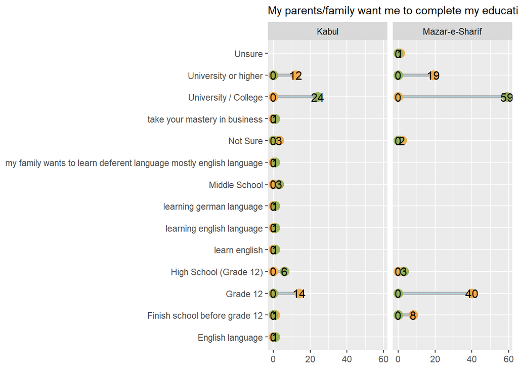

```r
Graphfunc(Education.CurrYear, "My parents/family want me to complete my education until", x="PreQ.rel.freq", xend="PostQ.rel.freq")
```

### Role model Skateistan Educator

```r
Role.Model.Skateistan.Educator.CurrYear <- Countfunc(PreQ.CurrYear,PostQ.CurrYear,"Role Model - Skateistan Educator")
```

```
##                    ID   Project.Site freq PreQ.rel.freq
## 1 Skateistan Educator          Kabul   34            24
## 2 Skateistan Educator Mazar-e-Sharif   61            42
## 3              Unsure          Kabul   10             7
## 4              Unsure Mazar-e-Sharif   39            27
##    ID   Project.Site freq PostQ.rel.freq
## 1  No Mazar-e-Sharif    1              1
## 2 Yes          Kabul   43             38
## 3 Yes Mazar-e-Sharif   69             61
```

```r
Role.Model.Skateistan.Educator.CurrYear
```

| Role Model - Skateistan Educator | Project.Site | freq.PreQ | PreQ.rel.freq | freq.PostQ | PostQ.rel.freq |
| --- | --- | --- | --- | --- | --- |
| No | Mazar-e-Sharif | 0 | 0 | 1 | 1 |
| Skateistan Educator | Kabul | 34 | 24 | 0 | 0 |
| Skateistan Educator | Mazar-e-Sharif | 61 | 42 | 0 | 0 |
| Unsure | Kabul | 10 | 7 | 0 | 0 |
| Unsure | Mazar-e-Sharif | 39 | 27 | 0 | 0 |
| Yes | Kabul | 0 | 0 | 43 | 38 |
| Yes | Mazar-e-Sharif | 0 | 0 | 69 | 61 |

Almost every student saw a Skateistan Educator as their role model by the end of the 2018-2019 school year, as opposed to just 66% at the start of the year

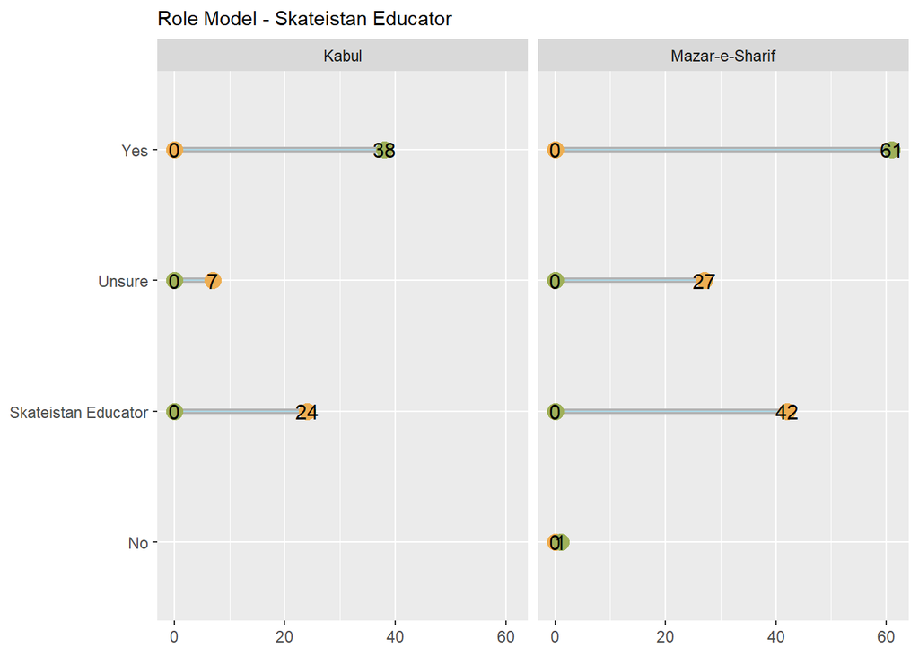

```r
Graphfunc(Role.Model.Skateistan.Educator.CurrYear, "Role Model - Skateistan Educator", x="PreQ.rel.freq", xend="PostQ.rel.freq")
```

### Open items

1. Public speaking exists only in 2018-2019. In PreQ, I believe I can share my ideas with the whole class can be coverted to public speaking
2. I like to help other students if they are struggling in the skatepark/classroom (empathy) in PreQ can be converted to helping others
3. Enjoy sport/skateboarding skills. I believe I can enjoy sport/skateboarding skills (sport needs to change to sports in PostQ). Only for 2018-2019
4. Gender stats from previous year has formatting issues
5. Current year confidence needs to be resolved
6. Learning usefull skills current year needs to be resolved
7. CurrYear friends to be added. The nature of the question has changed
8. Math previous year needs to be resolved
9. Formatting for 2017-2018 education needs to be fixed
10. Formatting for 2017-2018 Skateistan educator needs to be fixed
11. Wordclouds need final treatment to remove stopwords

WORDCLOUD CREATION (QUALITATIVE ANALYSIS)

```r
documents <- Corpus(VectorSource(PostQ.PrevYear))
documents = tm_map(documents, content_transformer(tolower))
documents = tm_map(documents, removePunctuation)
documents = tm_map(documents, removeWords, stopwords("english"))
```

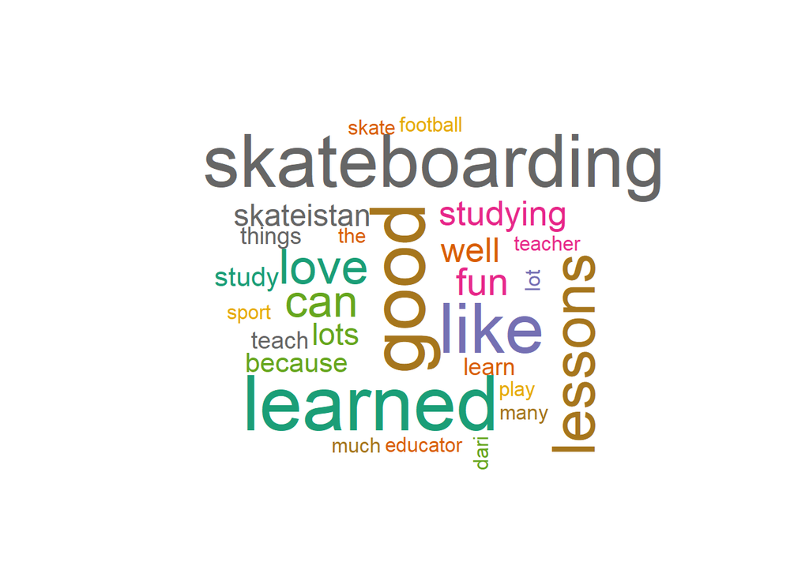

```r
wordcloud(PostQ.PrevYear$`Comment (experience coming to BTS classes)`,max.words = 200,random.color = TRUE,random.order=FALSE, colors=brewer.pal(8, "Dark2"))
```

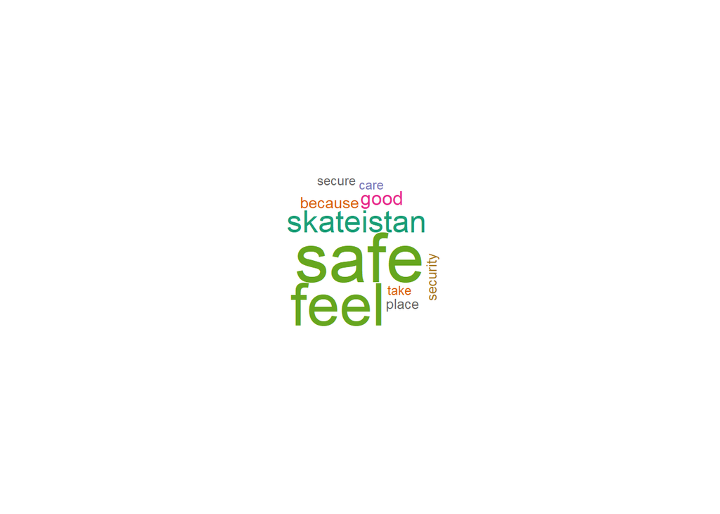

```r
wordcloud(PostQ.PrevYear$`Comment (safety at Skateistan)`,max.words = 200,random.color = TRUE,random.order=FALSE, colors=brewer.pal(8, "Dark2"), rot.per=0.35)
```

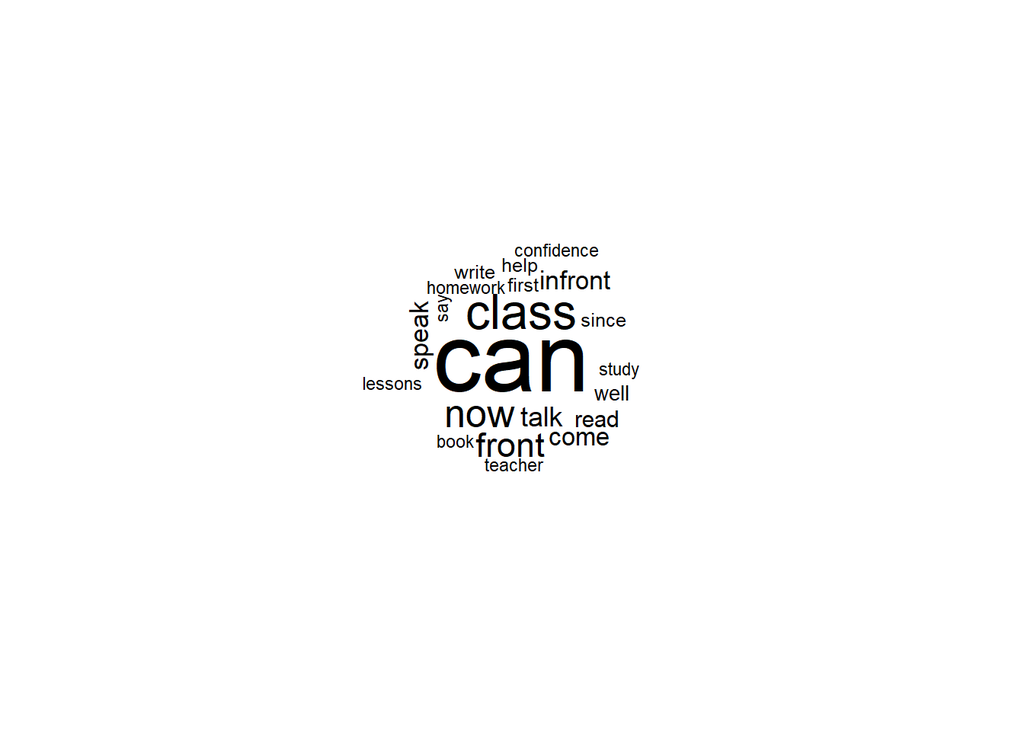

```r
wordcloud(PostQ.PrevYear$`Comment (confidence since joining Skateistan)`,max.words = 200,random.color = TRUE,random.order=FALSE)
```

[figure not shown]

```r
wordcloud(PostQ.PrevYear$`Role Model - Would you like to say who?`,max.words = 200,random.color = TRUE,random.order=FALSE)
```

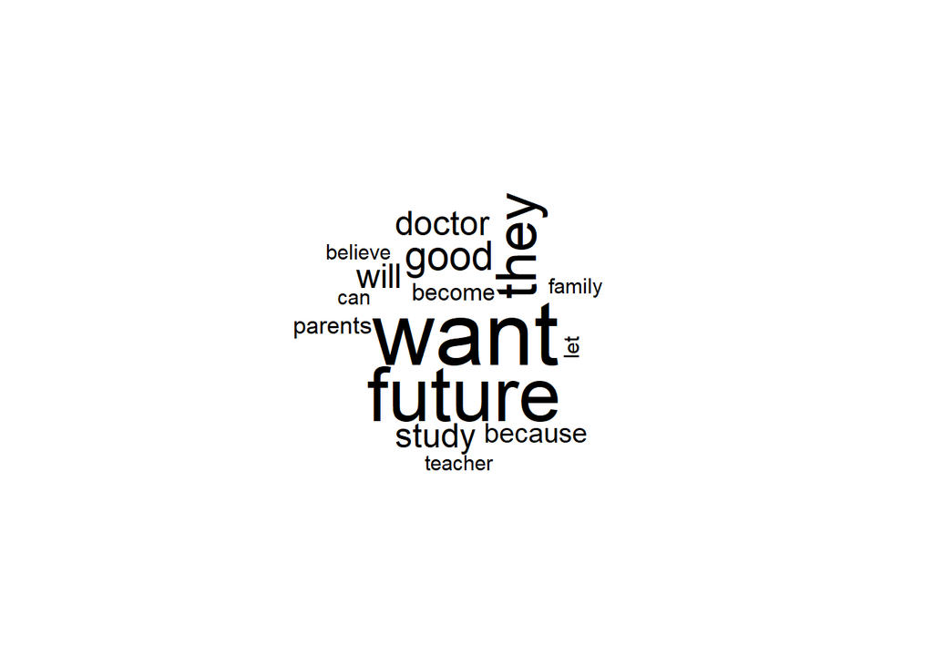

```r
wordcloud(PostQ.PrevYear$`Education level - Why/why not?`,max.words = 200,random.color = TRUE,random.order=FALSE)
```